# 00 - Definisanje problema

## Telco Customer Churn: predviđanje odliva korisnika

Pre nego što uopšte krenemo sa podacima, treba da bude jasno šta tačno predviđamo, zašto je to bitno i kako ćemo meriti da li model radi dobro.

Ovde nema obrade podataka — čisto uvodni sadržaj.

## 1. Kontekst

Telekomunikacione kompanije posluju na jako konkurentnom tržištu gde korisnici bez većih problema prelaze sa jednog provajdera na drugi. Kada korisnik napusti kompaniju, to se naziva odlivom korisnika (customer churn).

Zašto je to problem? Uglavnom zbog troškova — zadržati postojećeg korisnika je dosta jeftinije nego pridobiti novog. Zato se kompaniji više isplati da na vreme prepozna korisnike koji su u riziku od odlaska i pokuša da ih zadrži (popustom, boljom ponudom, pozivom podrške) nego da stalno juri nove.

Da bi to bilo moguće, kompanija mora unapred da zna ko će verovatno otići. To je i cilj ovog projekta: iz podataka o korisniku predvideti da li će napustiti kompaniju, kako bi se reagovalo na vreme.

## 2. Cilj našeg rada

Cilj je da napravimo model koji na osnovu podataka o korisniku predviđa vrednost kolone *Churn* — da li je korisnik otišao (*Yes*) ili ostao (*No*).

U terminima mašinskog učenja, ovo spada u nadgledano učenje (supervised learning), pošto za svakog korisnika iz skupa već znamo tačan ishod, pa model uči iz označenih primera. Konkretno, radi se o binarnoj klasifikaciji jer ciljna promenljiva ima samo dve moguće vrednosti (*Yes* / *No*).

Dakle, model ne predviđa broj (to bi bila regresija) nego kategoriju — svrstava korisnika u jednu od dve klase.

## 3. Opis skupa podataka

Telco Customer Churn skup sadrži podatke o 7.043 korisnika, raspoređene kroz 21 kolonu. Za svakog korisnika imamo osnovne podatke o njemu, koje usluge koristi, kakav ugovor ima, koliko i kako plaća i, ono što nas najviše zanima, da li je otišao iz kompanije.

Kolone se grubo mogu podeliti u četiri grupe:

**A. Demografija** — podaci o samom korisniku: gender, SeniorCitizen, Partner, Dependents

**B. Usluge** — šta korisnik koristi: PhoneService, MultipleLines, InternetService, OnlineSecurity, OnlineBackup, DeviceProtection, TechSupport, StreamingTV, StreamingMovies

**C. Nalog i plaćanje** — odnos korisnika sa kompanijom: tenure, Contract, PaperlessBilling, PaymentMethod, MonthlyCharges, TotalCharges

**D. Ciljna promenljiva:** `Churn` — da li je korisnik napustio kompaniju u prethodnom mesecu.

### Detaljan opis kolona

| Kolona | Opis | Tip |
| --- | --- | --- |
| `customerID` | Jedinstveni ID korisnika. Nema veze sa churn-om pa ga izbacujemo. | Identifikator |
| `gender` | Pol: `Female`, `Male`. | Kategorijska (nominalna) |
| `SeniorCitizen` | Da li je stariji građanin: `0` = ne, `1` = da. Zapisano kao broj, ali je zapravo kategorija. | Kategorijska (binarna) |
| `Partner` | Da li korisnik ima partnera: `Yes`, `No`. | Kategorijska (binarna) |
| `Dependents` | Da li izdržava nekoga (npr. decu): `Yes`, `No`. | Kategorijska (binarna) |
| `tenure` | Koliko meseci je korisnik u kompaniji. | Numerička (diskretna) |
| `PhoneService` | Da li ima telefonsku uslugu: `Yes`, `No`. | Kategorijska (binarna) |
| `MultipleLines` | Da li ima više linija: `Yes`, `No`, `No phone service`. | Kategorijska (nominalna) |
| `InternetService` | Tip interneta: `DSL`, `Fiber optic`, `No`. | Kategorijska (nominalna) |
| `OnlineSecurity` | Online zaštita: `Yes`, `No`, `No internet service`. | Kategorijska (nominalna) |
| `OnlineBackup` | Online backup: `Yes`, `No`, `No internet service`. | Kategorijska (nominalna) |
| `DeviceProtection` | Zaštita uređaja: `Yes`, `No`, `No internet service`. | Kategorijska (nominalna) |
| `TechSupport` | Tehnička podrška: `Yes`, `No`, `No internet service`. | Kategorijska (nominalna) |
| `StreamingTV` | Streaming TV: `Yes`, `No`, `No internet service`. | Kategorijska (nominalna) |
| `StreamingMovies` | Streaming filmova: `Yes`, `No`, `No internet service`. | Kategorijska (nominalna) |
| `Contract` | Tip ugovora: `Month-to-month`, `One year`, `Two year`. | Kategorijska (ordinalna) |
| `PaperlessBilling` | Bez papirnog računa: `Yes`, `No`. | Kategorijska (binarna) |
| `PaymentMethod` | Način plaćanja: `Electronic check`, `Mailed check`, `Bank transfer (automatic)`, `Credit card (automatic)`. | Kategorijska (nominalna) |
| `MonthlyCharges` | Mesečni iznos naplate. | Numerička (kontinualna) |
| `TotalCharges` | Ukupno naplaćeno do sada. | Numerička (kontinualna) |
| `Churn` | Ciljna promenljiva — da li je korisnik otišao: `Yes`, `No`. | Kategorijska (binarna) |

## 4. Izazovi u podacima

Već iz prvog pregleda skupa mogu se naslutiti neki problemi na koje ćemo morati da obratimo pažnju:

**Skrivene nedostajuće vrednosti u `TotalCharges`.** Ova kolona je učitana kao tekst iako bi trebalo da bude broj. Ispostavlja se da 11 korisnika umesto vrednosti ima prazan razmak. Problem je što ih **isnull()** ne prepoznaje kao nedostajuće, pa ćemo morati ručno da ih uhvatimo i konvertujemo kolonu u numerički tip.

**Nebalansirane klase.** Korisnika koji su ostali (`Churn = No`) ima oko 73%, a onih koji su otišli (`Churn = Yes`) oko 27%. Zbog ovog nebalansa obična tačnost (accuracy) nije baš pouzdana metrika, pa ćemo verovatno morati da posegnemo za balansiranjem klasa i prikladnijim metrikama.

**Vrednosti `"No internet service"` i `"No phone service"`.** Dosta kolona (npr. `OnlineSecurity`, `StreamingTV`) ima i treću vrednost tipa `No internet service`, i tu treba biti oprezan jer to nije isto što i `No`:

- `No` — korisnik ima internet, ali ne koristi tu dodatnu uslugu.
- `No internet service` — korisnik uopšte nema internet.

Kako ćemo ovo tretirati odlucicemo kasnije, u fazi pripreme podataka.

Pošto su klase nebalansirane (~73% naspram ~27%), tačnost (accuracy) nam ovde ne znači mnogo. Model koji bi bukvalno uvek predviđao `No` imao bi oko 73% tačnosti, a bio bi potpuno beskoristan — ne bi uhvatio nijednog korisnika koji stvarno odlazi.

Zato ćemo model gledati kroz sledeće metrike:

- **Precision** — od svih koje je model označio kao „otići će", koliko je zaista otišlo.
- **Recall** — od svih koji su stvarno otišli, koliko ih je model uhvatio. Govori koliko odlazaka propuštamo.
- **F1-score** — harmonijska sredina precision-a i recall-a, kad hoćemo jedan broj koji balansira ta dva.
- **AUC-ROC** — koliko dobro model razdvaja dve klase, nezavisno od praga odlučivanja.

Nama je posebno bitan recall za klasu `Yes`. Iz poslovnog ugla, propustiti korisnika koji će otići (pa ne reagovati na vreme) obično je skuplje nego pogrešno označiti lojalnog korisnika kao rizičnog. Na to ćemo obraćati pažnju pri evaluaciji.

Sve metrike računamo samo na test skupu, koji ne diramo ni u pripremi podataka ni u treniranju.

```python
# Uvozimo biblioteku pandas koja služi za rad sa tabelarnim podacima.
# Skraćenica "pd" je standardna konvencija — tako se pandas koristi svuda.
import pandas as pd


df = pd.read_csv("../WA_Fn-UseC_-Telco-Customer-Churn.csv")

# Prikazujemo dimenzije skupa: df.shape vraća (broj_redova, broj_kolona).
# [0] uzima prvi element (redove), [1] drugi (kolone).
print("Broj redova:", df.shape[0])
print("Broj kolona:", df.shape[1])

# df.head() prikazuje prvih 5 redova tabele da vidimo kako podaci izgledaju.
# Kada je poslednja linija u ćeliji, Jupyter je automatski lepo prikaže.
df.head()
```

```
Broj redova: 7043
Broj kolona: 21
```

|  | customerID | gender | SeniorCitizen | Partner | Dependents | tenure | PhoneService | MultipleLines | InternetService | OnlineSecurity | ... | DeviceProtection | TechSupport | StreamingTV | StreamingMovies | Contract | PaperlessBilling | PaymentMethod | MonthlyCharges | TotalCharges | Churn |
| --- | --- | --- | --- | --- | --- | --- | --- | --- | --- | --- | --- | --- | --- | --- | --- | --- | --- | --- | --- | --- | --- |
| 0 | 7590-VHVEG | Female | 0 | Yes | No | 1 | No | No phone service | DSL | No | ... | No | No | No | No | Month-to-month | Yes | Electronic check | 29.85 | 29.85 | No |
| 1 | 5575-GNVDE | Male | 0 | No | No | 34 | Yes | No | DSL | Yes | ... | Yes | No | No | No | One year | No | Mailed check | 56.95 | 1889.5 | No |
| 2 | 3668-QPYBK | Male | 0 | No | No | 2 | Yes | No | DSL | Yes | ... | No | No | No | No | Month-to-month | Yes | Mailed check | 53.85 | 108.15 | Yes |
| 3 | 7795-CFOCW | Male | 0 | No | No | 45 | No | No phone service | DSL | Yes | ... | Yes | Yes | No | No | One year | No | Bank transfer (automatic) | 42.30 | 1840.75 | No |
| 4 | 9237-HQITU | Female | 0 | No | No | 2 | Yes | No | Fiber optic | No | ... | No | No | No | No | Month-to-month | Yes | Electronic check | 70.70 | 151.65 | Yes |

5 rows × 21 columns

# 01 - Inicijalni pregled skupa podataka

U ovoj svesci prvi put zavirujemo u sirove podatke. Ideja je da se upoznamo sa strukturom skupa, pogledamo tipove podataka i uočimo eventualne probleme (nedostajuće vrednosti, duplikate, besmislene vrednosti) pre nego što bilo šta diramo.

Bitna napomena: ovde podatke samo posmatramo i dijagnostikujemo, ne menjamo ih. Čišćenje i obrada dolaze u kasnijim sveskama, tek nakon podele na trening i test skup.

## 1. Učitavanje podataka i biblioteka

Koristimo pandas, standardni alat za rad sa tabelarnim podacima u Python-u. Skup učitavamo iz CSV fajla u DataFrame — u suštini tabelu sa redovima i kolonama.

```python
#Prvi put importujemo biblioteku numpy (np) - za numeričke operacije; koristićemo ga kasnije za rad sa NaN vrednostima.
import pandas as pd
import numpy as np

# Podešavanje da pandas prikazuje SVE kolone kada ispisujemo tabelu.
# Bez ovoga, pandas skraćuje prikaz i sakriva srednje kolone sa "...".
pd.set_option("display.max_columns", None)


df = pd.read_csv("../WA_Fn-UseC_-Telco-Customer-Churn.csv")

print("Podaci su uspešno učitani.")
```

```
Podaci su uspešno učitani.
```

## 2. Dimenzije skupa podataka

Prvo proveravamo osnovne dimenzije — koliko redova (korisnika) i koliko kolona (atributa) skup sadrži.

```python
print("Broj redova (korisnika):", df.shape[0])
print("Broj kolona (atributa):", df.shape[1])
```

```
Broj redova (korisnika): 7043
Broj kolona (atributa): 21
```

## 3. Prvi pogled na podatke

Prikazujemo prvih nekoliko redova kako bismo videli konkretne vrednosti i stekli osećaj za sadržaj svake kolone.

```python
df.head()
```

|  | customerID | gender | SeniorCitizen | Partner | Dependents | tenure | PhoneService | MultipleLines | InternetService | OnlineSecurity | OnlineBackup | DeviceProtection | TechSupport | StreamingTV | StreamingMovies | Contract | PaperlessBilling | PaymentMethod | MonthlyCharges | TotalCharges | Churn |
| --- | --- | --- | --- | --- | --- | --- | --- | --- | --- | --- | --- | --- | --- | --- | --- | --- | --- | --- | --- | --- | --- |
| 0 | 7590-VHVEG | Female | 0 | Yes | No | 1 | No | No phone service | DSL | No | Yes | No | No | No | No | Month-to-month | Yes | Electronic check | 29.85 | 29.85 | No |
| 1 | 5575-GNVDE | Male | 0 | No | No | 34 | Yes | No | DSL | Yes | No | Yes | No | No | No | One year | No | Mailed check | 56.95 | 1889.5 | No |
| 2 | 3668-QPYBK | Male | 0 | No | No | 2 | Yes | No | DSL | Yes | Yes | No | No | No | No | Month-to-month | Yes | Mailed check | 53.85 | 108.15 | Yes |
| 3 | 7795-CFOCW | Male | 0 | No | No | 45 | No | No phone service | DSL | Yes | No | Yes | Yes | No | No | One year | No | Bank transfer (automatic) | 42.30 | 1840.75 | No |
| 4 | 9237-HQITU | Female | 0 | No | No | 2 | Yes | No | Fiber optic | No | No | No | No | No | No | Month-to-month | Yes | Electronic check | 70.70 | 151.65 | Yes |

## 4. Informacije o kolonama i tipovima podataka

`info()` nam daje pregled svih kolona: naziv, broj popunjenih (ne-null) vrednosti i tip podatka (`dtype`).

Ovo je zgodno za rano hvatanje problema. Najviše nas zanima da li se tipovi poklapaju sa onim što očekujemo — recimo, `TotalCharges` bi trebalo da bude broj, pa ako je učitana kao tekst (`object`), to je već znak da nešto nije kako treba.

```python
# df.info() ispisuje pregled: naziv kolone, broj ne-null vrednosti i tip podataka.
df.info()
```

```
<class 'pandas.core.frame.DataFrame'>
RangeIndex: 7043 entries, 0 to 7042
Data columns (total 21 columns):
 #   Column            Non-Null Count  Dtype
---  ------            --------------  -----
 0   customerID        7043 non-null   object
 1   gender            7043 non-null   object
 2   SeniorCitizen     7043 non-null   int64
 3   Partner           7043 non-null   object
 4   Dependents        7043 non-null   object
 5   tenure            7043 non-null   int64
 6   PhoneService      7043 non-null   object
 7   MultipleLines     7043 non-null   object
 8   InternetService   7043 non-null   object
 9   OnlineSecurity    7043 non-null   object
 10  OnlineBackup      7043 non-null   object
 11  DeviceProtection  7043 non-null   object
 12  TechSupport       7043 non-null   object
 13  StreamingTV       7043 non-null   object
 14  StreamingMovies   7043 non-null   object
 15  Contract          7043 non-null   object
 16  PaperlessBilling  7043 non-null   object
 17  PaymentMethod     7043 non-null   object
 18  MonthlyCharges    7043 non-null   float64
 19  TotalCharges      7043 non-null   object
 20  Churn             7043 non-null   object
dtypes: float64(1), int64(2), object(18)
memory usage: 1.1+ MB
```

## 5. Provera nedostajućih vrednosti

```python
# df.isnull() vraća tabelu True/False (True = vrednost nedostaje).
# .sum() sabira po kolonama: koliko True (nedostajućih) ima u svakoj koloni.
print("Broj nedostajućih vrednosti po kolonama:")
print(df.isnull().sum())
```

```
Broj nedostajućih vrednosti po kolonama:
customerID          0
gender              0
SeniorCitizen       0
Partner             0
Dependents          0
tenure              0
PhoneService        0
MultipleLines       0
InternetService     0
OnlineSecurity      0
OnlineBackup        0
DeviceProtection    0
TechSupport         0
StreamingTV         0
StreamingMovies     0
Contract            0
PaperlessBilling    0
PaymentMethod       0
MonthlyCharges      0
TotalCharges        0
Churn               0
dtype: int64
```

## 6. Skrivene nedostajuće vrednosti

Prethodna provera je pokazala da nema nedostajućih vrednosti, ali to zna da prevari. U praksi se nedostajuće vrednosti nekad kriju kao prazni razmaci (`" "`) umesto pravih `NaN` oznaka. `isnull()` ih ne uhvati jer su tehnički gledano tekst, a ne prazne vrednosti.

Zato dodatno proveravamo da li neka kolona sadrži vrednosti koje su samo prazan razmak.

```python
# Poredimo svaku ćeliju sa praznim razmakom " ".
# (df == " ") vraća tabelu True/False (True = ćelija sadrži tačno jedan razmak).
# .sum() sabira po kolonama koliko takvih "praznih" vrednosti ima.
print("Broj vrednosti koje su prazan razmak, po kolonama:")
print((df == " ").sum())
```

```
Broj vrednosti koje su prazan razmak, po kolonama:
customerID           0
gender               0
SeniorCitizen        0
Partner              0
Dependents           0
tenure               0
PhoneService         0
MultipleLines        0
InternetService      0
OnlineSecurity       0
OnlineBackup         0
DeviceProtection     0
TechSupport          0
StreamingTV          0
StreamingMovies      0
Contract             0
PaperlessBilling     0
PaymentMethod        0
MonthlyCharges       0
TotalCharges        11
Churn                0
dtype: int64
```

## 7. Analiza problema sa kolonom `TotalCharges`

Sad je jasno zašto je `TotalCharges` prepoznata kao tekst (`object`) umesto broja: pošto 11 vrednosti sadrži prazan razmak (a to nije broj), pandas je celu kolonu protumačio kao tekstualnu.

```python
# pd.to_numeric() pokušava da pretvori kolonu u broj.
# errors="coerce" znači: vrednosti koje se NE mogu pretvoriti u broj postaju NaN umesto da izazovu grešku.
df["TotalCharges"] = pd.to_numeric(df["TotalCharges"], errors="coerce")

# Ponovo proveravamo nedostajuće vrednosti — sada bi TotalCharges trebalo da pokaže 11 NaN vrednosti.
print("Broj nedostajućih vrednosti nakon konverzije TotalCharges:")
print(df.isnull().sum())
```

```
Broj nedostajućih vrednosti nakon konverzije TotalCharges:
customerID           0
gender               0
SeniorCitizen        0
Partner              0
Dependents           0
tenure               0
PhoneService         0
MultipleLines        0
InternetService      0
OnlineSecurity       0
OnlineBackup         0
DeviceProtection     0
TechSupport          0
StreamingTV          0
StreamingMovies      0
Contract             0
PaperlessBilling     0
PaymentMethod        0
MonthlyCharges       0
TotalCharges        11
Churn                0
dtype: int64
```

Zaključak je da `TotalCharges` treba da bude numerička kolona, pa je konvertujemo.

```python
df["TotalCharges"] = pd.to_numeric(df["TotalCharges"],errors="coerce")
```

## 8. Analiza korisnika sa nedostajućim `TotalCharges`

Sad kad je `TotalCharges` numerička, možemo da vidimo tačno koliko korisnika ima nedostajuću vrednost. Hoćemo i da razumemo zašto baš oni — da li je posredi slučajna greška ili tu postoji neki obrazac.

```python
print("Nedostajuće vrednosti nakon konverzije TotalCharges:")
print(df.isnull().sum())
print()
```

```
Nedostajuće vrednosti nakon konverzije TotalCharges:
customerID           0
gender               0
SeniorCitizen        0
Partner              0
Dependents           0
tenure               0
PhoneService         0
MultipleLines        0
InternetService      0
OnlineSecurity       0
OnlineBackup         0
DeviceProtection     0
TechSupport          0
StreamingTV          0
StreamingMovies      0
Contract             0
PaperlessBilling     0
PaymentMethod        0
MonthlyCharges       0
TotalCharges        11
Churn                0
dtype: int64
```

### Ključna opservacija

Svih 11 korisnika sa nedostajućom vrednošću `TotalCharges` ima `tenure = 0`. To su, dakle, korisnici koji su tek počeli da koriste uslugu, pa u trenutku formiranja skupa za njih još nije bilo evidentirane ukupne naplate.

Ovo nam dosta govori. Nije u pitanju slučajna greška u merenju niti namerno preskočeno polje — vrednost jednostavno logički ne postoji za te korisnike (nova pretplata, naplate još nije bilo).

Šta ćemo sa ovim redovima, odlučićemo kasnije, nakon podele na trening i test skup, da ne bismo napravili curenje informacija (data leakage).

Zaključak je da nedostajuće vrednosti ipak postoje u skupu, pa u sledećem koraku utvrđujemo koje su tačno.

```python
print("Korisnici sa nedostajućim TotalCharges:")
print(df[df["TotalCharges"].isnull()])
print()
```

```
Korisnici sa nedostajućim TotalCharges:
      customerID  gender  SeniorCitizen Partner Dependents  tenure  \
488   4472-LVYGI  Female              0     Yes        Yes       0
753   3115-CZMZD    Male              0      No        Yes       0
936   5709-LVOEQ  Female              0     Yes        Yes       0
1082  4367-NUYAO    Male              0     Yes        Yes       0
1340  1371-DWPAZ  Female              0     Yes        Yes       0
3331  7644-OMVMY    Male              0     Yes        Yes       0
3826  3213-VVOLG    Male              0     Yes        Yes       0
4380  2520-SGTTA  Female              0     Yes        Yes       0
5218  2923-ARZLG    Male              0     Yes        Yes       0
6670  4075-WKNIU  Female              0     Yes        Yes       0
6754  2775-SEFEE    Male              0      No        Yes       0

     PhoneService     MultipleLines InternetService       OnlineSecurity  \
```

[output cut: 50 more lines]

## 9. Provera duplikata

Proveravamo da li skup sadrži duplirane redove, kao i da li se neki `customerID` pojavljuje više puta. Duplikati mogu iskriviti kasnije analize i modeliranje.

```python
print("Broj dupliranih redova:", df.duplicated().sum())
print("Broj dupliranih customerID vrednosti:",df["customerID"].duplicated().sum())
print()
```

```
Broj dupliranih redova: 0
Broj dupliranih customerID vrednosti: 0
```

Zakljucujemo da `nema duplikata` u nasem skupu podataka

## 10. Osnovna statistika numeričkih promenljivih

Za numeričke kolone (`SeniorCitizen`, `tenure`, `MonthlyCharges`, `TotalCharges`) `describe()` daje osnovne pokazatelje: broj vrednosti, prosek, standardnu devijaciju, minimum, maksimum i kvartile.

Ovo nam koristi da vidimo u kom se rasponu vrednosti kreću (npr. najveća/najmanja mesečna naplata), da uhvatimo eventualne besmislice (negativne vrednosti tamo gde ih ne sme biti) i da steknemo grubu sliku o raspodeli pre detaljnije analize u narednim sveskama.

```python
print("Osnovna statistika numeričkih promenljivih:")
print(df[["SeniorCitizen", "tenure","MonthlyCharges", "TotalCharges"]].describe())
print()
```

```
Osnovna statistika numeričkih promenljivih:
       SeniorCitizen       tenure  MonthlyCharges  TotalCharges
count    7043.000000  7043.000000     7043.000000   7032.000000
mean        0.162147    32.371149       64.761692   2283.300441
std         0.368612    24.559481       30.090047   2266.771362
min         0.000000     0.000000       18.250000     18.800000
25%         0.000000     9.000000       35.500000    401.450000
50%         0.000000    29.000000       70.350000   1397.475000
75%         0.000000    55.000000       89.850000   3794.737500
max         1.000000    72.000000      118.750000   8684.800000
```

### Tumačenje osnovne statistike

Par stvari koje se odmah vide:

- `tenure` ide od 0 do 72 meseca (znači do 6 godina). Ona nula se odnosi na onih 11 korisnika sa nedostajućim `TotalCharges` koje smo malopre našli.
- `MonthlyCharges` se kreće od oko 18 do oko 119 dolara, bez negativnih i besmislenih vrednosti.
- `TotalCharges` ide od oko 18 do oko 8.685 dolara. Broj vrednosti je 7032 umesto 7043 jer 11 redova ima `NaN`, što se poklapa sa prethodnom analizom.
- `SeniorCitizen` je prikazana kao broj (0 i 1), ali je zapravo binarna kategorija, pa `describe()` nad njom nema mnogo smisla — bolja je provera raspodele kategorija.

## 11. Provera kategorijskih promenljivih

### 11.1 SeniorCitizen — binarna kategorija u brojnom obliku

`SeniorCitizen` je zapisana kao broj (0 ili 1), ali je suštinski binarna kategorija: da li je korisnik stariji građanin ili ne. Zato umesto statistike gledamo raspodelu po vrednostima, da vidimo koliko korisnika pada u svaku grupu.

```python
print("Raspodela SeniorCitizen:")
print(df["SeniorCitizen"].value_counts())
print()
```

```
Raspodela SeniorCitizen:
SeniorCitizen
0    5901
1    1142
Name: count, dtype: int64
```

Većina korisnika (~5.900, oko 84%) nisu stariji građani, dok ih je manjina (~1.140, oko 16%) u toj grupi. Ova nesrazmera će nam biti bitna kasnije — proverićemo da li starost korisnika ima veze sa odlivom.

Izdvajamo sve kolone koje imaju tekstualne vrednosti.

Za svaku kategoriju prikazujemo sve *`postojece`* kategorije i *`broj`* korisnika u svakoj kategoriji

### 11.2 Sve kategorijske promenljive

Prolazimo kroz sve kolone tekstualnog tipa (`object`) i za svaku ispisujemo postojeće kategorije zajedno sa brojem korisnika. Tako vidimo tačno koje se vrednosti javljaju, da li ima nekih neočekivanih ili nekonzistentnih kategorija i koliko su kategorije izbalansirane (da li negde jedna vrednost dominira).

`customerID` preskačemo — tih 7043 jedinstvenih identifikatora nema šta da nam kaže u ovakvom prikazu.

```python
# Izdvajamo sve kolone tekstualnog tipa.
categorical_columns = df.select_dtypes(include="object").columns

# Za svaku kategorijsku kolonu prikazujemo raspodelu.
# Izuzimamo customerID jer predstavlja jedinstveni identifikator korisnika,
# a ne kategoriju za analizu.
for column in categorical_columns:
    if column == "customerID":
        continue
    print(f"\n{column}:")
    print(df[column].value_counts())
```

```
gender:
gender
Male      3555
Female    3488
Name: count, dtype: int64

Partner:
Partner
No     3641
Yes    3402
Name: count, dtype: int64

Dependents:
Dependents
No     4933
Yes    2110
Name: count, dtype: int64

PhoneService:
PhoneService
Yes    6361
No      682
Name: count, dtype: int64

MultipleLines:
MultipleLines
No                  3390
Yes                 2971
No phone service     682
Name: count, dtype: int64

InternetService:
InternetService
Fiber optic    3096
DSL            2421
No             1526
Name: count, dtype: int64

OnlineSecurity:
OnlineSecurity
```

[output cut: 51 more lines]

```
Name: count, dtype: int64

PaymentMethod:
PaymentMethod
Electronic check             2365
Mailed check                 1612
Bank transfer (automatic)    1544
Credit card (automatic)      1522
Name: count, dtype: int64

Churn:
Churn
No     5174
Yes    1869
Name: count, dtype: int64
```

### Tumačenje kategorijskih promenljivih

**Balansirane binarne kolone:**

- `gender`: Male 3555, Female 3488 — praktično 50-50
- `Partner`: No 3641, Yes 3402 — malo više onih bez partnera

**Nebalansirane binarne kolone:**

- `Dependents`: No 4933, Yes 2110 — većina nema zavisne osobe
- `PhoneService`: Yes 6361, No 682 — skoro svi imaju telefonsku uslugu
- `PaperlessBilling`: Yes 4171, No 2872

**Kolone sa tri vrednosti (`Yes` / `No` / `"No internet service"` i sl.** `MultipleLines`, `OnlineSecurity`, `OnlineBackup`, `DeviceProtection`, `TechSupport`, `StreamingTV`, `StreamingMovies`.

`"No internet service"` i `"No"` nisu isto: `"No"` — korisnik ima internet, ali ne koristi tu dodatnu uslugu `"No internet service"` — korisnik uopšte nema internet Ova razlika će biti bitna za feature engineering, pa ćemo o tome (spajati ih ili ne) odlučiti kasnije.

Klase su nebalansirane, što će direktno uticati na izbor metrika i na strategiju modeliranja.

## 12. Zaključak

Kroz inicijalni pregled skupa `Telco Customer Churn` došli smo do sledećeg.

**Struktura skupa:** 7.043 korisnika i 21 kolona, koje smo podelili u 4 grupe — demografske, usluge, podaci o nalogu i plaćanju, i ciljna promenljiva.

**Problemi koje ćemo rešavati:**

1. Skrivene nedostajuće vrednosti u `TotalCharges` — 11 korisnika (0.16%) sa `tenure = 0`. Posle konverzije u broj ti redovi imaju `NaN`. Šta ćemo sa njima, odlučujemo tek nakon podele na trening/test.
2. `SeniorCitizen` je zapisana kao 0/1 iako je binarna kategorija. Razmislićemo o konverziji u `No`/`Yes` radi konzistentnosti.
3. Vrednosti `"No internet service"` i `"No phone service"` nisu isto što i `"No"`. O njihovom tretmanu odlučujemo u fazi pripreme podataka.
4. Nebalansirane klase u `Churn` (~73% No, ~27% Yes), što dosta utiče na izbor metrika i na pristup modeliranju.

**Ono što je u redu:**

- Nema duplikata (ni potpunih redova ni po `customerID`)
- Numeričke kolone nemaju nelogične vrednosti (negativne ili van opsega)
- Kategorijske kolone imaju konzistentne vrednosti, bez tipfelera

# 02 - Detekcija sistematskih (logičkih) grešaka

Pošto smo prošli inicijalni pregled, ovde tražimo logičke nekonzistentnosti između kolona — kombinacije vrednosti koje nisu statistički čudne, ali su logički nemoguće ili bar sumnjive.

Ovakve stvari `isnull()`, `describe()` ili box-plot neće uhvatiti, jer je svaka vrednost sama za sebe sasvim u redu. Problem iskoči tek kad pogledaš odnose između kolona.

Napomena: ovo radimo pre podele na trening i test skup, pošto su u pitanju strukturne provere koje ne zavise od statistike podataka. Nemoguća kombinacija je nemoguća bez obzira na raspodelu.

## 1. Učitavanje podataka

Učitavamo isti skup kao u prethodnoj svesci i radimo istu konverziju `TotalCharges` u broj, da bismo krenuli od istog stanja podataka na kom smo završili u svesci `01`.

```python
import pandas as pd
import numpy as np

pd.set_option("display.max_columns", None)

df = pd.read_csv("../WA_Fn-UseC_-Telco-Customer-Churn.csv")
df["TotalCharges"] = pd.to_numeric(df["TotalCharges"], errors="coerce")

print(f"Podaci ucitani: {df.shape[0]} redova x {df.shape[1]} kolona")
```

```
Podaci ucitani: 7043 redova x 21 kolona
```

## 2. Konzistentnost: PhoneService <-> MultipleLines

Logika je sledeća: ako korisnik nema telefonsku uslugu (`PhoneService = No`), onda `MultipleLines` mora biti `"No phone service"`. Bilo šta drugo (`"Yes"` ili `"No"`) nema smisla — kako bi neko imao ili nemao više telefonskih linija ako uopšte nema telefon?

Proveravamo da li ovo važi za sve redove.

```python
# Izdvajamo redove gde korisnik nema telefonsku uslugu.
# df["PhoneService"] == "No" vraća seriju True/False za svaki red.
bez_telefona = df[df["PhoneService"] == "No"]

print(f"Broj korisnika bez telefonske usluge: {len(bez_telefona)}")

# Za te korisnike, prikazujemo koje vrednosti imaju u MultipleLines.
# Očekivanje: sve treba da bude "No phone service".
print("\nVrednosti MultipleLines za korisnike bez telefonske usluge:")
print(bez_telefona["MultipleLines"].value_counts())
```

```
Broj korisnika bez telefonske usluge: 682

Vrednosti MultipleLines za korisnike bez telefonske usluge:
MultipleLines
No phone service    682
Name: count, dtype: int64
```

### Rezultat provere

Svih 682 korisnika bez telefonske usluge ima vrednost `"No phone service"` u koloni `MultipleLines`. Znači konzistentno je, nema logičkih grešaka između ove dve kolone.

## 3. Konzistentnost: InternetService <-> dodatne internet usluge

Ista priča kao malopre: ako korisnik nema internet (`InternetService = No`), onda sve dodatne internet usluge moraju imati vrednost `"No internet service"`. Sve drugo bi bilo nemoguće — kako bi neko imao online zaštitu, backup ili streaming bez interneta?

Dodatne internet usluge su `OnlineSecurity`, `OnlineBackup`, `DeviceProtection`, `TechSupport`, `StreamingTV` i `StreamingMovies`.

Ovaj put, dakle, proveravamo konzistentnost preko 6 kolona odjednom.

```python
# Izdvajamo redove gde korisnik nema internet uslugu.
bez_interneta = df[df["InternetService"] == "No"]

print(f"Broj korisnika bez internet usluge: {len(bez_interneta)}")

# Lista dodatnih internet usluga koje proveravamo.
dodatne_usluge = [
    "OnlineSecurity", "OnlineBackup", "DeviceProtection",
    "TechSupport", "StreamingTV", "StreamingMovies"
]

# Za svaku od tih kolona prikazujemo raspodelu vrednosti kod korisnika bez interneta.
# Očekivanje: sve treba da bude "No internet service".
print("\nRaspodela vrednosti za korisnike bez interneta:")
for usluga in dodatne_usluge:
    print(f"\n{usluga}:")
    print(bez_interneta[usluga].value_counts())
```

```
Broj korisnika bez internet usluge: 1526

Raspodela vrednosti za korisnike bez interneta:

OnlineSecurity:
OnlineSecurity
No internet service    1526
Name: count, dtype: int64

OnlineBackup:
OnlineBackup
No internet service    1526
Name: count, dtype: int64

DeviceProtection:
DeviceProtection
No internet service    1526
Name: count, dtype: int64

TechSupport:
TechSupport
No internet service    1526
Name: count, dtype: int64

StreamingTV:
StreamingTV
No internet service    1526
Name: count, dtype: int64

StreamingMovies:
StreamingMovies
No internet service    1526
Name: count, dtype: int64
```

### Rezultat provere

Svih 1526 korisnika bez interneta ima vrednost `"No internet service"` u svih 6 dodatnih usluga (`OnlineSecurity`, `OnlineBackup`, `DeviceProtection`, `TechSupport`, `StreamingTV`, `StreamingMovies`). Konzistentno je, nema logičkih grešaka oko internet usluga.

## 4. Efikasnija provera pomoću vektorizovanih operacija

```python
# Za svaku dodatnu uslugu proveravamo koliko korisnika BEZ interneta ima
# vrednost različitu od "No internet service" (što bi bila logička greška).

print("Broj problematičnih redova po koloni:")


for usluga in dodatne_usluge:
    broj_problema = (bez_interneta[usluga] != "No internet service").sum()
    print(f"  {usluga}: {broj_problema}")
```

```
Broj problematičnih redova po koloni:
  OnlineSecurity: 0
  OnlineBackup: 0
  DeviceProtection: 0
  TechSupport: 0
  StreamingTV: 0
  StreamingMovies: 0
```

## 5. Provera korisnika sa `tenure = 0`

`tenure` je broj meseci koliko je korisnik u kompaniji, pa vrednost `0` znači korisnike koji su tek počeli.

Ovo proveravamo da vidimo koliko takvih „novih" korisnika ima i da eksplicitno potvrdimo ono što već znamo iz sveske `01` — da su to isti oni kod kojih fali `TotalCharges`.

```python
# Broj korisnika sa tenure = 0.
tenure_nula = df[df["tenure"] == 0]
print(f"Broj korisnika sa tenure = 0: {len(tenure_nula)}")

# Provera: da li se to poklapa sa brojem korisnika kojima fali TotalCharges?
totalcharges_nan = df[df["TotalCharges"].isnull()]
print(f"Broj korisnika sa TotalCharges = NaN: {len(totalcharges_nan)}")

# print(set(tenure_nula["customerID"]))
# print(set(totalcharges_nan["customerID"]))
isti_korisnici = set(tenure_nula["customerID"]) == set(totalcharges_nan["customerID"])
print(f"Da li su to isti korisnici? {isti_korisnici}")
```

```
Broj korisnika sa tenure = 0: 11
Broj korisnika sa TotalCharges = NaN: 11
Da li su to isti korisnici? True
```

### Rezultat provere

U skupu ima 11 korisnika sa `tenure = 0`. Poređenje `customerID` vrednosti potvrđuje da su to iste osobe kojima je nedostajao `TotalCharges`.

Ti korisnici su tehnički ispravni (tek su se pretplatili), ali će zbog nedostajućeg `TotalCharges` dobiti poseban tretman u narednim sveskama, nakon podele na trening/test.

## 6. Zaključak

Provera sistematskih grešaka pokazuje da je skup logički konzistentan.

Prošle su sve tri provere:

1. Svi korisnici bez telefonske usluge imaju `MultipleLines = "No phone service"`.
2. Svi korisnici bez interneta imaju `"No internet service"` u svih 6 dodatnih usluga.
3. Korisnici sa `tenure = 0` su ista grupa kod koje fali `TotalCharges`.

Za dalji rad ovo znači da kolone `MultipleLines`, `OnlineSecurity`, `OnlineBackup`, `DeviceProtection`, `TechSupport`, `StreamingTV` i `StreamingMovies` nose konzistentnu informaciju o tome da usluga ne postoji (`"No phone service"` / `"No internet service"`). Odatle se otvara prostor za feature engineering — možemo razmišljati o spajanju `"No"` i `"No internet service"` u istu kategoriju ili o pravljenju novih izvedenih atributa.

# 03 - Podela na trening i test skup

Ovo je verovatno najvažniji korak u celom projektu: podela podataka na trening (train) i test skup.

Vazan je zato što sve što radimo dalje (detekcija outliera, imputacija, feature engineering, skaliranje) mora da se oslanja samo na trening skup. Test skup diramo tek jednom, na samom kraju, za finalnu evaluaciju.

Time sprečavamo curenje informacija (**data leakage**) i obezbeđujemo da evaluacija bude poštena — da stvarno pokaže kako će se model ponašati na podacima koje ranije nije video.

## 1. Učitavanje podataka i strukturne popravke

Učitavamo skup i radimo dve strukturne popravke koje smo najavili ranije:

1. Konverzija `TotalCharges` u broj — pošto je 11 vrednosti sadržalo prazan razmak, cela kolona je bila učitana kao tekst.
2. Uklanjanje tih 11 redova sa `NaN` u `TotalCharges` — reč je o korisnicima sa `tenure = 0` (tek pristigli, još nenaplaćeni). Ima ih zanemarljivo malo (0.16%), a njihova specifičnost bi mogla da unese šum.

Napomena: ove popravke su strukturne — ne zavise od raspodele podataka nego su posledica objektivnih problema u sirovom fajlu. Zato ih radimo pre split-a, bez rizika od data leakage-a.

```python
import pandas as pd
import numpy as np

# train_test_split je funkcija za podelu podataka na trening i test skup.
from sklearn.model_selection import train_test_split


pd.set_option("display.max_columns", None)

df = pd.read_csv("../WA_Fn-UseC_-Telco-Customer-Churn.csv")


df["TotalCharges"] = pd.to_numeric(df["TotalCharges"], errors="coerce")

# Strukturna popravka 2: brisanje 11 redova sa NaN u TotalCharges.
# Ovo su korisnici sa tenure=0 (novi, još nisu naplaćeni).
df = df.dropna(subset=["TotalCharges"])

# .reset_index(drop=True) resetuje indekse (redne brojeve) redova.
df = df.reset_index(drop=True)

print(f"Nakon strukturnih popravki: {df.shape[0]} redova × {df.shape[1]} kolona")
```

```
Nakon strukturnih popravki: 7032 redova × 21 kolona
```

## 2. Razdvajanje atributa (X) od ciljne promenljive (y)

Pre podele na train/test razdvajamo dve stvari:

- `X` — atributi (features) na osnovu kojih model uči i predviđa
- `y` — ciljna promenljiva (target) koju predviđamo, tj. `Churn`

Uz to izbacujemo `customerID`, pošto je to samo jedinstveni identifikator bez prediktivne vrednosti — svaki korisnik ima svoj ID, pa tu nema obrasca koji bi model mogao da nauči.

Oko oznaka: veliko `X` se po konvenciji koristi za matricu atributa (više kolona), a malo `y` za vektor ciljne promenljive (jedna kolona).

```python
# Definišemo ciljnu promenljivu (y) — kolonu koju predviđamo.
y = df["Churn"]

# Definišemo matricu atributa (X) — sve kolone OSIM Churn-a i customerID-a.
# df.drop(columns=[...]) vraća novi DataFrame bez tih kolona.
# customerID izbacujemo jer nema prediktivnu vrednost.
# Churn izbacujemo jer je to ciljna promenljiva (ne sme biti među atributima).
X = df.drop(columns=["customerID", "Churn"])

# Proveravamo dimenzije.
print(f"X (atributi): {X.shape[0]} redova × {X.shape[1]} kolona")
print(f"y (ciljna promenljiva): {y.shape[0]} vrednosti")
print(f"\nAtributi u X: {list(X.columns)}")
```

```
X (atributi): 7032 redova × 19 kolona
y (ciljna promenljiva): 7032 vrednosti

Atributi u X: ['gender', 'SeniorCitizen', 'Partner', 'Dependents', 'tenure', 'PhoneService', 'MultipleLines', 'InternetService', 'OnlineSecurity', 'OnlineBackup', 'DeviceProtection', 'TechSupport', 'StreamingTV', 'StreamingMovies', 'Contract', 'PaperlessBilling', 'PaymentMethod', 'MonthlyCharges', '…
```

## 3. Podela na trening i test skup

Sada delimo podatke na dva skupa:

- Trening (80%) — na njemu radimo sve dalje analize, transformacije i treniranje modela.
- Test (20%) — zaključavamo ga do kraja i koristimo samo za finalnu evaluaciju.

Parametri koje prosleđujemo:

- `test_size=0.2` — 20% podataka ide u test skup.
- `stratify=y` — stratifikacija po ciljnoj promenljivoj, da proporcija klasa (Yes/No) bude ista u train i test skupu. Kod nebalansiranog skupa kao što je naš (~73% : ~27%) ovo je bitno.
- `random_state=42` — fiksira „seme" slučajnog procesa, pa svako pokretanje daje istu podelu. Bez toga nema ponovljivosti eksperimenata.
- `shuffle=True` — redovi se prvo izmešaju, da eventualni redosled u sirovim podacima ne utiče na podelu (npr. da svi noviji korisnici ne završe na kraju).

```python
# Delimo X i y na train i test skup jednim pozivom funkcije.
# train_test_split vraća 4 objekta u fiksnom redosledu:
#   X_train, X_test, y_train, y_test
# Redosled je uvek ovakav — X pre y, train pre test.
X_train, X_test, y_train, y_test = train_test_split(
    X,                    # matrica atributa
    y,                    # ciljna promenljiva
    test_size=0.2,        # 20% za test
    stratify=y,           # stratifikacija po ciljnoj promenljivoj
    random_state=42,      # fiksiramo slučajnost za ponovljivost
    shuffle=True          # izmešaj redove pre podele
)

# Prikazujemo dimenzije oba skupa da potvrdimo podelu.
print("Dimenzije nakon podele:")
print(f"  X_train: {X_train.shape[0]} redova x {X_train.shape[1]} kolona")
print(f"  X_test:  {X_test.shape[0]} redova x {X_test.shape[1]} kolona")
print(f"  y_train: {y_train.shape[0]} vrednosti")
print(f"  y_test:  {y_test.shape[0]} vrednosti")

# Procentualno odnos
ukupno = X_train.shape[0] + X_test.shape[0]
print(f"\nProcenat train: {100 * X_train.shape[0] / ukupno:.2f}%")
print(f"Procenat test:  {100 * X_test.shape[0] / ukupno:.2f}%")
```

```
Dimenzije nakon podele:
  X_train: 5625 redova x 19 kolona
  X_test:  1407 redova x 19 kolona
  y_train: 5625 vrednosti
  y_test:  1407 vrednosti

Procenat train: 79.99%
Procenat test:  20.01%
```

## 4. Provera stratifikacije

Posle podele proveravamo da li je stratifikacija stvarno odradila posao — da proporcija klasa `Churn` bude ista (ili skoro ista) u train i test skupu.

Ako se procenti bitno razlikuju, nešto ne valja i treba videti šta.

```python
# Procentualna raspodela Churn u originalnom skupu, train skupu i test skupu.
# normalize=True vraća proporcije umesto apsolutnih brojeva.
print("Proporcije Churn klasa:")
print("\nOriginalni skup:")
print(y.value_counts(normalize=True) * 100)

print("\nTrain skup:")
print(y_train.value_counts(normalize=True) * 100)

print("\nTest skup:")
print(y_test.value_counts(normalize=True) * 100)
```

```
Proporcije Churn klasa:

Originalni skup:
Churn
No     73.421502
Yes    26.578498
Name: proportion, dtype: float64

Train skup:
Churn
No     73.422222
Yes    26.577778
Name: proportion, dtype: float64

Test skup:
Churn
No     73.418621
Yes    26.581379
Name: proportion, dtype: float64
```

### Rezultat provere

Proporcije klase `Churn` su skoro identične u sva tri skupa (originalni, train, test) — svuda odnos oko 73.4% : 26.6%. Stratifikacija je, dakle, prošla kako treba i oba skupa su reprezentativna po ciljnoj promenljivoj.

Praktično, to znači da će evaluacija na test skupu biti poštena — odnos klasa koji model vidi pri evaluaciji odgovara stvarnom odnosu u populaciji.

## 5. Čuvanje train i test skupova u fajlove

Da ne bi svaki put iznova radili učitavanje, konverziju i split, sačuvaćemo trenutno stanje train i test skupova u `data/processed/`.

Za format biramo CSV — čitljiv je, univerzalan i lako se otvara u bilo čemu (Excel, Python, R). Moglo bi i Parquet (brži i manji), ali za naših 7.032 reda CSV je sasvim dovoljan.

Čuvamo četiri fajla:

- `X_train.csv` i `y_train.csv` — trening podaci
- `X_test.csv` i `y_test.csv` — test podaci (ne diramo ih do kraja)

```python
putanja = "../data/processed/"

# index=False znači: ne čuvaj indekse (redne brojeve) kao dodatnu kolonu u CSV-u.
# Ako bismo ostavili default (index=True), pri sledećem učitavanju bismo dobili
# suvišnu kolonu "Unnamed: 0" — svima na nervima i beskorisnu.
X_train.to_csv(putanja + "X_train.csv", index=False)
X_test.to_csv(putanja + "X_test.csv", index=False)
y_train.to_csv(putanja + "y_train.csv", index=False)
y_test.to_csv(putanja + "y_test.csv", index=False)

print("Fajlovi uspešno sačuvani u folder 'data/processed/':")
print("  - X_train.csv")
print("  - X_test.csv")
print("  - y_train.csv")
print("  - y_test.csv")
```

```
Fajlovi uspešno sačuvani u folder 'data/processed/':
  - X_train.csv
  - X_test.csv
  - y_train.csv
  - y_test.csv
```

## 6. Verifikacija: učitavanje fajlova nazad

Kao završna provera, učitavamo sačuvane fajlove nazad i uveravamo se da su dimenzije očuvane. Ovo je važno jer sledeće sveske startuju baš iz ovih fajlova

```python
# Učitavamo fajlove nazad da proverimo da je čuvanje bilo korektno.
X_train_check = pd.read_csv(putanja + "X_train.csv")
X_test_check = pd.read_csv(putanja + "X_test.csv")
y_train_check = pd.read_csv(putanja + "y_train.csv")
y_test_check = pd.read_csv(putanja + "y_test.csv")

print("Dimenzije nakon učitavanja iz fajlova:")
print(f"  X_train: {X_train_check.shape[0]} × {X_train_check.shape[1]}")
print(f"  X_test:  {X_test_check.shape[0]} × {X_test_check.shape[1]}")
print(f"  y_train: {y_train_check.shape[0]}")
print(f"  y_test:  {y_test_check.shape[0]}")

# Provera identičnosti — dimenzije treba da se poklope sa originalnim.
provere = [
    X_train.shape == X_train_check.shape,
    X_test.shape == X_test_check.shape,
    y_train.shape[0] == y_train_check.shape[0],
    y_test.shape[0] == y_test_check.shape[0],
]

if all(provere):
    print("\nSve dimenzije se poklapaju. Fajlovi su korektno sačuvani.")
else:
    print("\nUPOZORENJE: dimenzije se ne poklapaju — istražiti problem!")
```

```
Dimenzije nakon učitavanja iz fajlova:
  X_train: 5625 × 19
  X_test:  1407 × 19
  y_train: 5625
  y_test:  1407

Sve dimenzije se poklapaju. Fajlovi su korektno sačuvani.
```

## 7. Zaključak

U ovoj svesci smo odradili ono što je verovatno najvažniji korak u projektu — podelu podataka na trening i test skup.

Ukratko, šta je urađeno:

1. Strukturne popravke — konverzija `TotalCharges` u broj i uklanjanje 11 redova sa nedostajućim vrednostima.
2. Razdvajanje `X` i `y` — atributi (19 kolona) odvojeni od ciljne promenljive (`Churn`).
3. Stratifikovana podela — 80% train, 20% test, uz očuvanje proporcija klasa u oba skupa.
4. Provera — proporcije `Churn` su praktično iste u train i test skupu (~73.4% / ~26.6%).
5. Čuvanje — sva četiri objekta (`X_train`, `X_test`, `y_train`, `y_test`) sačuvana u `data/processed/`.

Dimenzije posle podele: train ima 5.625 korisnika (80%), test 1.407 (20%).

Princip kojeg se od sada držimo: sve odluke, analize i transformacije rade se samo na trening skupu. Test skup ne otvaramo, ne analiziramo i ne koristimo ni za kakvo računanje statistika sve do kraja projekta, kada služi za finalnu evaluaciju modela.

# 04 - Detekcija statističkih anomalija (outliera)

Ova sveska je prvi korak istraživačke analize, u njoj detektujemo statistička odstupanja (outliere) u numeričkim kolonama.

Za to koristimo neparametarski pristup baziran na box-plotu i IQR pravilu (Interquartile Range). Granice za outliere definišemo kao:

- Donja granica: `Q1 − 1.5 × IQR`
- Gornja granica: `Q3 + 1.5 × IQR`

Ovakav pristup biramo jer ne pretpostavlja normalnu raspodelu podataka, radi na bilo kakvom obliku raspodele i pritom je intuitivno razumljiv.

Kao i do sada, sve analize u ovoj svesci radimo isključivo na trening skupu (`X_train`), dok test skup ostaje netaknut do kraja projekta, radi sprečavanja data leakage-a.

## 1. Učitavanje trening skupa

Umesto ponavljanja svih prethodnih koraka (učitavanje sirovog CSV-a, konverzija, split), direktno učitavamo već pripremljen trening skup iz foldera `data/processed/`

```python
# Uvozimo osnovne biblioteke.
import pandas as pd
import numpy as np

import matplotlib.pyplot as plt

# seaborn je nadgradnja matplotlib-a — daje lepše grafike sa manje koda.
import seaborn as sns

# Podešavanja za prikaz.
pd.set_option("display.max_columns", None)

# Podešavanje stila za seaborn grafike — beli background sa mrežom.
sns.set_style("whitegrid")

# Podrazumevana veličina grafika (širina, visina u inčima).
plt.rcParams["figure.figsize"] = (10, 6)

# Učitavamo trening skup atributa (X_train) iz prethodne sveske.
X_train = pd.read_csv("../data/processed/X_train.csv")

print(f"Trening skup učitan: {X_train.shape[0]} redova × {X_train.shape[1]} kolona")
```

```
Trening skup učitan: 5625 redova × 19 kolona
```

## 2. Identifikacija numeričkih kolona za analizu

Box-plot i IQR pravilo primenjujemo samo na numeričke kolone. U našem skupu to su:

- `tenure`
- `MonthlyCharges`
- `TotalCharges`

Kolonu `SeniorCitizen` ne uključujemo, iako je zapisana kao broj (0/1), jer je konceptualno binarna kategorija, a box-plot na binarnoj vrednosti nema mnogo smisla, dobili bismo samo dve tačke.

```python
# Definišemo listu numeričkih kolona koje analiziramo.
numericke_kolone = ["tenure", "MonthlyCharges", "TotalCharges"]

# Osnovna statistika ovih kolona na trening skupu.
print("Osnovna statistika numeričkih kolona (trening skup):")
X_train[numericke_kolone].describe()
```

```
Osnovna statistika numeričkih kolona (trening skup):
```

|  | tenure | MonthlyCharges | TotalCharges |
| --- | --- | --- | --- |
| count | 5625.000000 | 5625.000000 | 5625.000000 |
| mean | 32.562311 | 64.999316 | 2301.839520 |
| std | 24.542421 | 30.108642 | 2275.586084 |
| min | 1.000000 | 18.400000 | 18.800000 |
| 25% | 9.000000 | 35.800000 | 413.000000 |
| 50% | 29.000000 | 70.600000 | 1410.250000 |
| 75% | 56.000000 | 90.050000 | 3801.700000 |
| max | 72.000000 | 118.650000 | 8684.800000 |

## 3. Analiza kolone `tenure`

`tenure` pokazuje koliko meseci je korisnik kod kompanije. Očekivane vrednosti idu od 0 (novi korisnici) do 72 (najstariji, 6 godina).

Gledamo je kroz dva prikaza: box-plot, koji pokazuje kvartile, medijanu i eventualne outliere, i histogram sa krivom, koji pokazuje oblik raspodele same po sebi.

Posle vizuelne inspekcije, prebrojaćemo outliere i numerički, pomoću IQR pravila (`Q1 − 1.5×IQR`, `Q3 + 1.5×IQR`).

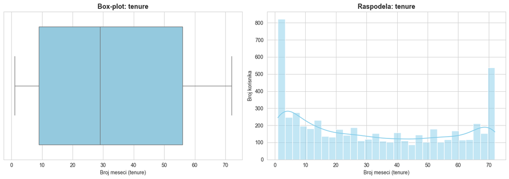

```python
# Pravimo figuru sa dva grafika jedan pored drugog.
fig, axes = plt.subplots(1, 2, figsize=(14, 5))


sns.boxplot(x=X_train["tenure"], ax=axes[0], color="skyblue")
axes[0].set_title("Box-plot: tenure", fontsize=13, fontweight="bold")
axes[0].set_xlabel("Broj meseci (tenure)")



sns.histplot(X_train["tenure"], bins=30, kde=True, ax=axes[1], color="skyblue")
axes[1].set_title("Raspodela: tenure", fontsize=13, fontweight="bold")
axes[1].set_xlabel("Broj meseci (tenure)")
axes[1].set_ylabel("Broj korisnika")


plt.tight_layout()

plt.savefig("../images/04_tenure_distribution.png", dpi=100, bbox_inches="tight")

plt.show()
```

### IQR računica za `tenure`

Sada isto proveravamo i numerički, računamo granice outliera po IQR pravilu.

```python
Q1 = X_train["tenure"].quantile(0.25)
Q3 = X_train["tenure"].quantile(0.75)
IQR = Q3 - Q1

# Granice za outliere.
donja_granica = Q1 - 1.5 * IQR
gornja_granica = Q3 + 1.5 * IQR

# Brojimo koliko vrednosti pada van granica.To cemo uraditi preko uslova i sa funkcijom sum() cemo ih prebrojati.
outliers_mask = (X_train["tenure"] < donja_granica) | (X_train["tenure"] > gornja_granica)
broj_outliera = outliers_mask.sum()

# Ispisujemo rezultate.
print(f"Kolona: tenure")
print(f"  Q1 (25. percentil): {Q1:.2f}")
print(f"  Q3 (75. percentil): {Q3:.2f}")
print(f"  IQR: {IQR:.2f}")
print(f"  Donja granica (Q1 - 1.5*IQR): {donja_granica:.2f}")
print(f"  Gornja granica (Q3 + 1.5*IQR): {gornja_granica:.2f}")
print(f"  Broj outliera: {broj_outliera} ({100*broj_outliera/len(X_train):.2f}%)")
```

```
Kolona: tenure
  Q1 (25. percentil): 9.00
  Q3 (75. percentil): 56.00
  IQR: 47.00
  Donja granica (Q1 - 1.5*IQR): -61.50
  Gornja granica (Q3 + 1.5*IQR): 126.50
  Broj outliera: 0 (0.00%)
```

### Tumačenje za `tenure`

Raspodela je bimodalna, ima dva izražena vrha: jedan na malim vrednostima (oko 0-5 meseci), što su nove pretplate, i drugi na velikim vrednostima (oko 70+ meseci), dugogodišnji korisnici. Ovo ima smisla i sugeriše da postoje dve različite grupe korisnika, oni koji se brzo odluče (ili ostanu ili odu), i oni koji su lojalni dugoročno.

Iz ovoga možemo zaključiti da nema potrebe za uklanjanjem ili transformacijom outliera u ovoj koloni.

## 4. Analiza kolone `MonthlyCharges`

`MonthlyCharges` pokazuje koliko korisnik plaća mesečno. Vrednosti očekujemo u razumnom opsegu, od oko 18$ za osnovnu uslugu do oko 120$ za najskuplji paket sa svim dodacima.

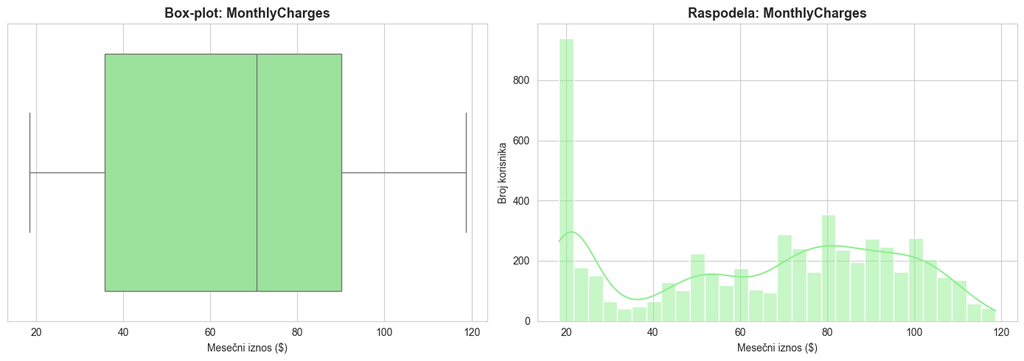

```python
# Ista struktura kao za tenure
fig, axes = plt.subplots(1, 2, figsize=(14, 5))

# Box-plot
sns.boxplot(x=X_train["MonthlyCharges"], ax=axes[0], color="lightgreen")
axes[0].set_title("Box-plot: MonthlyCharges", fontsize=13, fontweight="bold")
axes[0].set_xlabel("Mesečni iznos ($)")

# Histogram
sns.histplot(X_train["MonthlyCharges"], bins=30, kde=True, ax=axes[1], color="lightgreen")
axes[1].set_title("Raspodela: MonthlyCharges", fontsize=13, fontweight="bold")
axes[1].set_xlabel("Mesečni iznos ($)")
axes[1].set_ylabel("Broj korisnika")

plt.tight_layout()
plt.savefig("../images/04_monthly_charges_distribution.png", dpi=100, bbox_inches="tight")
plt.show()
```

```python
# IQR računica za MonthlyCharges.
Q1 = X_train["MonthlyCharges"].quantile(0.25)
Q3 = X_train["MonthlyCharges"].quantile(0.75)
IQR = Q3 - Q1

donja_granica = Q1 - 1.5 * IQR
gornja_granica = Q3 + 1.5 * IQR

outliers_mask = (X_train["MonthlyCharges"] < donja_granica) | (X_train["MonthlyCharges"] > gornja_granica)
broj_outliera = outliers_mask.sum()

print(f"Kolona: MonthlyCharges")
print(f"  Q1 (25. percentil): {Q1:.2f}")
print(f"  Q3 (75. percentil): {Q3:.2f}")
print(f"  IQR: {IQR:.2f}")
print(f"  Donja granica (Q1 - 1.5*IQR): {donja_granica:.2f}")
print(f"  Gornja granica (Q3 + 1.5*IQR): {gornja_granica:.2f}")
print(f"  Broj outliera: {broj_outliera} ({100*broj_outliera/len(X_train):.2f}%)")
```

```
Kolona: MonthlyCharges
  Q1 (25. percentil): 35.80
  Q3 (75. percentil): 90.05
  IQR: 54.25
  Donja granica (Q1 - 1.5*IQR): -45.58
  Gornja granica (Q3 + 1.5*IQR): 171.43
  Broj outliera: 0 (0.00%)
```

### Tumačenje za `MonthlyCharges`

Raspodela je višemodalna, vidi se nekoliko izraženih vrhova koji odgovaraju različitim tipovima paketa: osnovni telefonski paket oko 20$, srednji paketi oko 70-80$, i kompletni paketi sa svim dodacima ka 100$+. Primetno je da je najjeftiniji paket od 20$ znatno dominantniji u odnosu na ostale tipove.

Prema IQR pravilu, nema outliera ni u ovoj koloni, sve vrednosti padaju unutar granica [Q1 - 1.5*IQR, Q3 + 1.5*IQR]. Ovo je i očekivano, jer su cene paketa ograničene poslovnom logikom, postoji jasan minimum i maksimum onoga što korisnik može mesečno da plati.

Ni ovde, dakle, nema potrebe za uklanjanjem ili transformacijom.

## 5. Analiza kolone `TotalCharges`

`TotalCharges` pokazuje ukupan iznos koji je korisnik platio od početka korišćenja usluge. Za razliku od `MonthlyCharges`, ova kolona je kumulativna, odnosno što je korisnik duže kod kompanije, to joj je vrednost veća.

Zbog te kumulativne prirode, očekujemo desno iskošenu raspodelu: mnogo korisnika sa malim `TotalCharges` (novi korisnici ili oni sa manjim paketima), i manje njih sa velikim vrednostima (dugogodišnji korisnici sa skupljim paketima).

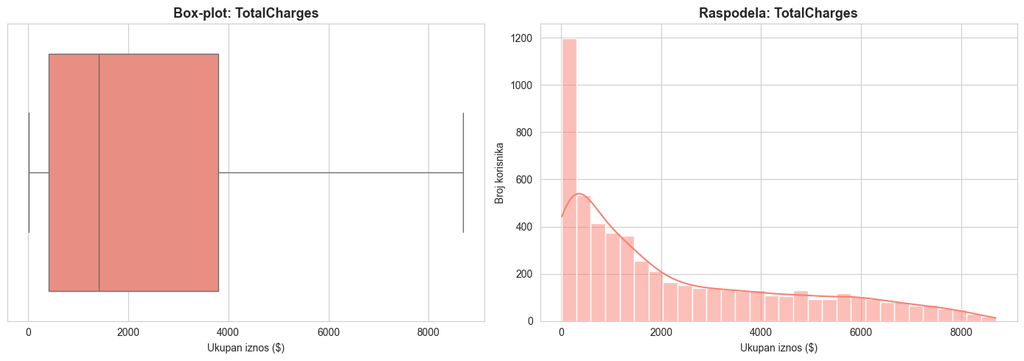

```python
fig, axes = plt.subplots(1, 2, figsize=(14, 5))

# Box-plot
sns.boxplot(x=X_train["TotalCharges"], ax=axes[0], color="salmon")
axes[0].set_title("Box-plot: TotalCharges", fontsize=13, fontweight="bold")
axes[0].set_xlabel("Ukupan iznos ($)")

# Histogram
sns.histplot(X_train["TotalCharges"], bins=30, kde=True, ax=axes[1], color="salmon")
axes[1].set_title("Raspodela: TotalCharges", fontsize=13, fontweight="bold")
axes[1].set_xlabel("Ukupan iznos ($)")
axes[1].set_ylabel("Broj korisnika")

plt.tight_layout()
plt.savefig("../images/04_total_charges_distribution.png", dpi=100, bbox_inches="tight")
plt.show()
```

```python
# IQR računica za TotalCharges.
Q1 = X_train["TotalCharges"].quantile(0.25)
Q3 = X_train["TotalCharges"].quantile(0.75)
IQR = Q3 - Q1

donja_granica = Q1 - 1.5 * IQR
gornja_granica = Q3 + 1.5 * IQR

outliers_mask = (X_train["TotalCharges"] < donja_granica) | (X_train["TotalCharges"] > gornja_granica)
broj_outliera = outliers_mask.sum()

print(f"Kolona: TotalCharges")
print(f"  Q1 (25. percentil): {Q1:.2f}")
print(f"  Q3 (75. percentil): {Q3:.2f}")
print(f"  IQR: {IQR:.2f}")
print(f"  Donja granica (Q1 - 1.5*IQR): {donja_granica:.2f}")
print(f"  Gornja granica (Q3 + 1.5*IQR): {gornja_granica:.2f}")
print(f"  Broj outliera: {broj_outliera} ({100*broj_outliera/len(X_train):.2f}%)")
```

```
Kolona: TotalCharges
  Q1 (25. percentil): 413.00
  Q3 (75. percentil): 3801.70
  IQR: 3388.70
  Donja granica (Q1 - 1.5*IQR): -4670.05
  Gornja granica (Q3 + 1.5*IQR): 8884.75
  Broj outliera: 0 (0.00%)
```

### Tumačenje za `TotalCharges`

Raspodela je desno iskošena, kako smo i očekivali zbog kumulativne prirode kolone. Većina korisnika ima male vrednosti (novi korisnici ili oni sa nižim paketima), a broj korisnika sa visokim vrednostima postepeno opada.

Prema IQR pravilu, nema formalnih outliera, sve vrednosti padaju unutar granica. Iako raspodela ima dugačak rep udesno, IQR pravilo ga toleriše zbog samog rasporeda kvartila.

Vredi napomenuti da bi ova iskošenost mogla biti relevantna za neke modele, posebno linearne, koji pretpostavljaju normalnost. Kasnije, prilikom pripreme podataka, razmotrićemo eventualnu log-transformaciju kolone `TotalCharges` kao način da se iskošenost smanji.

Kao i kod prethodne dve kolone, nema potrebe za uklanjanjem outliera, transformacija oblika ostaje moguća opcija za kasnije.

## 6. Zaključak

Detekcija anomalija na trening skupu pokazuje da je skup statistički čist:

| Kolona | Q1 | Q3 | IQR | Broj outliera |
| --- | --- | --- | --- | --- |
| `tenure` | 9.00 | 56.00 | 47.00 | 0 |
| `MonthlyCharges` | 35.80 | 90.05 | 54.25 | 0 |
| `TotalCharges` | 413.00 | 3801.70 | 3388.70 | 0 |

Prema IQR pravilu, nijedna od tri numeričke kolone ne sadrži outliere. `tenure` ima bimodalnu raspodelu, sa dva vrha koja odgovaraju novim i dugogodišnjim korisnicima, `MonthlyCharges` je višemodalna i odražava strukturu paketa (osnovni, srednji, kompletni), dok je `TotalCharges` desno iskošena zbog svoje kumulativne prirode.

Za sada ne uklanjamo nijedan podatak, jer su sve vrednosti legitimne. Jedino što ostavljamo kao mogućnost za kasnije je log-transformacija kolone `TotalCharges`, radi smanjenja iskošenosti.

# 05 - Priprema podataka za mašinsko učenje

U ovoj svesci sirove trening i test skupove pretvaramo u oblik koji algoritmi mašinskog učenja mogu da koriste. Sve odluke donosimo gledajući isključivo trening skup, a onda iste transformacije primenjujemo i na test.

Prolazimo kroz dva glavna koraka:

1. Feature engineering, spajanje kategorija, konverzija tipova i kreiranje novih atributa
2. Enkodiranje kategorija, odnosno pretvaranje teksta u brojeve, i to pomoću Label, Ordinal i One-Hot enkodiranja

Na kraju čuvamo pripremljene podatke.

## 1. Učitavanje trening i test skupova

Učitavamo sva četiri objekta koja smo sačuvali u svesci `03`: `X_train`, `X_test`, `y_train`, `y_test`.

```python
import pandas as pd
import numpy as np
import os

pd.set_option("display.max_columns", None)

putanja_processed = "../data/processed/"

X_train = pd.read_csv(putanja_processed + "X_train.csv")
X_test = pd.read_csv(putanja_processed + "X_test.csv")
y_train = pd.read_csv(putanja_processed + "y_train.csv")
y_test = pd.read_csv(putanja_processed + "y_test.csv")

# y_train i y_test su učitani kao DataFrame sa jednom kolonom, pretvaramo ih u Series.
y_train = y_train.squeeze()
y_test = y_test.squeeze()

print("Učitani podaci:")
print(f"  X_train: {X_train.shape[0]} × {X_train.shape[1]}")
print(f"  X_test:  {X_test.shape[0]} × {X_test.shape[1]}")
print(f"  y_train: {y_train.shape[0]}")
print(f"  y_test:  {y_test.shape[0]}")
```

```
Učitani podaci:
  X_train: 5625 × 19
  X_test:  1407 × 19
  y_train: 5625
  y_test:  1407
```

## 2. Feature engineering

Pre enkodiranja prolazimo kroz nekoliko transformacija atributa.

### 2.1 Spajanje "No internet service" i "No"

Šest kolona (`OnlineSecurity`, `OnlineBackup`, `DeviceProtection`, `TechSupport`, `StreamingTV`, `StreamingMovies`) ima tri moguće vrednosti: `Yes`, `No`, `No internet service`.

Sa poslovne strane, „korisnik nema tu uslugu" znači isto bez obzira da li je razlog to što ima internet ali nije uzeo tu opciju, ili prosto nema internet uopšte. Zato `No internet service` svodimo na `No`.

Isto radimo i sa kolonom `MultipleLines`, gde vrednost `No phone service` takođe postaje `No`.

```python
kolone_no_internet = [
    "OnlineSecurity", "OnlineBackup", "DeviceProtection",
    "TechSupport", "StreamingTV", "StreamingMovies"
]


for kolona in kolone_no_internet:
    X_train[kolona] = X_train[kolona].replace("No internet service", "No")
    X_test[kolona] = X_test[kolona].replace("No internet service", "No")


X_train["MultipleLines"] = X_train["MultipleLines"].replace("No phone service", "No")
X_test["MultipleLines"] = X_test["MultipleLines"].replace("No phone service", "No")

# Provera - sada te kolone treba da imaju samo "Yes" i "No".
print("Vrednosti nakon spajanja:")
for kolona in kolone_no_internet + ["MultipleLines"]:
    print(f"  {kolona}: {sorted(X_train[kolona].unique())}")
```

```
Vrednosti nakon spajanja:
  OnlineSecurity: ['No', 'Yes']
  OnlineBackup: ['No', 'Yes']
  DeviceProtection: ['No', 'Yes']
  TechSupport: ['No', 'Yes']
  StreamingTV: ['No', 'Yes']
  StreamingMovies: ['No', 'Yes']
  MultipleLines: ['No', 'Yes']
```

### 2.2 Konverzija `SeniorCitizen` u tekstualnu binarnu kategoriju

`SeniorCitizen` je zapisana kao broj (0/1), iako je zapravo binarna kategorija. Zato je pretvaramo u `No`/`Yes`, da bude ista po formatu kao ostale binarne kolone, i da kasnije sve njih možemo enkodirati istom logikom.

```python
#proveravamo sa if-om da bi obezbedili sigurnost od veceg broja pokretanja
if X_train["SeniorCitizen"].dtype != "object":
    mapiranje_senior = {0: "No", 1: "Yes"}
    X_train["SeniorCitizen"] = X_train["SeniorCitizen"].map(mapiranje_senior)
    X_test["SeniorCitizen"] = X_test["SeniorCitizen"].map(mapiranje_senior)
print("SeniorCitizen vrednosti nakon konverzije:")
print(X_train["SeniorCitizen"].value_counts())
```

```
SeniorCitizen vrednosti nakon konverzije:
SeniorCitizen
No     4715
Yes     910
Name: count, dtype: int64
```

### 2.3 Kreiranje broja aktivnih dodatnih usluga

Ovde gledamo šest dodatnih usluga (`OnlineSecurity`, `OnlineBackup`, `DeviceProtection`, `TechSupport`, `StreamingTV`, `StreamingMovies`) i za svakog korisnika brojimo koliko ih ima aktivno (vrednost `Yes`).

Dobijena kolona `ActiveServices` je nova numerička promenljiva, i može nam pokazati da li broj korišćenih usluga ima veze sa tim da li korisnik ostaje ili odlazi.

```python
usluge = [
    "OnlineSecurity",
    "OnlineBackup",
    "DeviceProtection",
    "TechSupport",
    "StreamingTV",
    "StreamingMovies"
]

X_train["ActiveServices"] = (X_train[usluge] == "Yes").sum(axis=1)
X_test["ActiveServices"] = (X_test[usluge] == "Yes").sum(axis=1)

print("Raspodela broja aktivnih dodatnih usluga:")
print(X_train["ActiveServices"].value_counts().sort_index())
```

```
Raspodela broja aktivnih dodatnih usluga:
ActiveServices
0    1740
1     770
2     835
3     902
4     688
5     468
6     222
Name: count, dtype: int64
```

```python
X_train[usluge + ["ActiveServices"]].head()
```

|  | OnlineSecurity | OnlineBackup | DeviceProtection | TechSupport | StreamingTV | StreamingMovies | ActiveServices |
| --- | --- | --- | --- | --- | --- | --- | --- |
| 0 | Yes | Yes | Yes | Yes | No | No | 4 |
| 1 | No | No | Yes | Yes | No | No | 2 |
| 2 | No | Yes | Yes | Yes | No | No | 3 |
| 3 | No | Yes | No | No | No | Yes | 2 |
| 4 | Yes | No | No | No | Yes | No | 2 |

### 2.4 Grupisanje korisnika prema dužini pretplate

`tenure` pokazuje koliko meseci korisnik već koristi uslugu. Da bi analiza bila preglednija, te vrednosti grupišemo u četiri kategorije:

- `0-12 meseci`
- `13-24 meseca`
- `25-48 meseci`
- `49+ meseci`

Tako umesto pojedinačnog broja meseci dobijamo kategoriju, koju je lakše tumačiti dalje u analizi.

### 2.5 Kreiranje izvedenog atributa `TenureGroup`

Pored sirove kolone `tenure`, uvodimo i grupisanu verziju `TenureGroup` koja korisnike svrstava u četiri kategorije po dužini staža:

- `0-12 meseci` — novi korisnici (najveći rizik od odlaska)
- `13-24 meseca` — korisnici u ranoj fazi
- `25-48 meseci` — stabilni srednjoročni korisnici
- `49+ meseci` — dugogodišnji lojalni korisnici

Grupisanje pravimo iz dva razloga:

1. **Vizualizacije** — u multivarijantnim heatmapima u svesci `06` mnogo je čitljivije prikazati 4 grupe nego 72 pojedinačne vrednosti tenure-a.
2. **Alternativni prikaz podatka za modele** — modeli mogu drugačije da reaguju na diskretne kategorije nego na sirovi broj meseci.

Enkodiramo ordinalno (0-3) jer redosled kategorija ima poslovni smisao (kraća -> duža lojalnost).

**Napomena o multikolinearnosti:** `TenureGroup` je izveden iz `tenure`, pa su ove dve kolone visoko korelisane. Kod linearnih modela izbacićemo `TenureGroup` (zajedno sa `TotalCharges`) da izbegnemo multikolinearnost. Kod modela baziranih na stablima zadržavamo obe kolone.

```python
# Grupe prema dužini pretplate:
# 0-12 meseci   → novi korisnici (do 1 godine)
# 13-24 meseca  → korisnici sa 1-2 godine pretplate
# 25-48 meseci  → korisnici sa 2-4 godine pretplate
# 49+ meseci    → dugogodišnji korisnici (više od 4 godine)

granice_tenure = [0, 12, 24, 48, float("inf")]
nazivi_tenure = [
    "0-12 meseci",
    "13-24 meseca",
    "25-48 meseci",
    "49+ meseci"
]

X_train["TenureGroup"] = pd.cut(
    X_train["tenure"],
    bins=granice_tenure,
    labels=nazivi_tenure,
    include_lowest=True
)

X_test["TenureGroup"] = pd.cut(
    X_test["tenure"],
    bins=granice_tenure,
    labels=nazivi_tenure,
    include_lowest=True
)

print("Raspodela korisnika po grupama tenure:")
print(X_train["TenureGroup"].value_counts().sort_index())
```

```
Raspodela korisnika po grupama tenure:
TenureGroup
0-12 meseci     1724
13-24 meseca     818
25-48 meseci    1279
49+ meseci      1804
Name: count, dtype: int64
```

## 3. Enkodiranje kategorijskih promenljivih

Sledeći korak je pretvaranje tekstualnih kolona u brojeve. U zavisnosti od tipa kategorije koristimo jednu od tri metode:

- Label Encoding (0/1), za binarne kolone (`Yes`/`No`)
- Ordinal Encoding, za kategorije koje imaju prirodan redosled
- One-Hot Encoding, za nominalne kolone sa više od dve vrednosti

### Pregled kolona po metodi:

[output not shown]

`tenure`, `MonthlyCharges` i `TotalCharges` ostaju kakve jesu, pošto su već numeričke.

### 3.1 Label Encoding za binarne kolone

Sve binarne kolone (`Yes`/`No`) enkodiramo na isti način: `Yes → 1`, `No → 0`.

```python
binarne_kolone = [
    "gender", "SeniorCitizen", "Partner", "Dependents", "PhoneService",
    "MultipleLines", "OnlineSecurity", "OnlineBackup", "DeviceProtection",
    "TechSupport", "StreamingTV", "StreamingMovies", "PaperlessBilling"
]

# kolona "gender" ima "Male"/"Female", ne "Yes"/"No". Zbog toga resavamo je zasebno pre opšteg mapiranja.
mapiranje_gender = {"Male": 1, "Female": 0}
X_train["gender"] = X_train["gender"].map(mapiranje_gender)
X_test["gender"] = X_test["gender"].map(mapiranje_gender)


# Opšte mapiranje za ostale binarne kolone (Yes/No).
mapiranje_yes_no = {"Yes": 1, "No": 0}
for kolona in binarne_kolone:
    if kolona == "gender":
        continue
    X_train[kolona] = X_train[kolona].map(mapiranje_yes_no)
    X_test[kolona] = X_test[kolona].map(mapiranje_yes_no)


print("Prve 3 vrste nakon Label enkodiranja binarnih kolona:")
X_train[binarne_kolone].head(3)
```

```
Prve 3 vrste nakon Label enkodiranja binarnih kolona:
```

|  | gender | SeniorCitizen | Partner | Dependents | PhoneService | MultipleLines | OnlineSecurity | OnlineBackup | DeviceProtection | TechSupport | StreamingTV | StreamingMovies | PaperlessBilling |
| --- | --- | --- | --- | --- | --- | --- | --- | --- | --- | --- | --- | --- | --- |
| 0 | 1 | 0 | 1 | 1 | 1 | 1 | 1 | 1 | 1 | 1 | 0 | 0 | 0 |
| 1 | 1 | 0 | 0 | 0 | 0 | 0 | 0 | 0 | 1 | 1 | 0 | 0 | 0 |
| 2 | 0 | 0 | 1 | 0 | 1 | 1 | 0 | 1 | 1 | 1 | 0 | 0 | 0 |

### 3.2 One-Hot Encoding za `Contract`

`Contract` ima tri vrednosti koje na prvi pogled idu jedna za drugom po logici:

- `Month-to-month` (najkraći i najfleksibilniji, ali i najrizičniji za odlazak)
- `One year` (srednji)
- `Two year` (najduži, korisnici najlojalniji)

Na početku smo razmišljali da ih enkodiramo ordinalno (`0 → 1 → 2`), pošto postoji prirodan redosled. Ali kad smo u EDA pogledali kako `Contract` utiče na Churn, videli smo da efekat NIJE linearan: Month-to-month ima ~43% churn, One year ~11%, a Two year ~3%. Razlike između susednih kategorija nisu jednake (pad sa 43 na 11 nije isti kao sa 11 na 3).

Kod linearnih modela poput Logističke regresije, ordinalno kodiranje bi model naterao da pretpostavi jednake razmake između kategorija, pa bi izgubio ovu nelinearnu informaciju. Zato koristimo **One-Hot Encoding**, koji svakoj kategoriji daje svoju kolonu, pa model može da nauči zasebnu težinu za svaku.

Sa `drop_first=True` izbacujemo jednu kategoriju kao referentnu, da izbegnemo savršenu kolinearnost (ista logika kao kod ostalih One-Hot kolona).

Modelima na stablima (Random Forest, XGBoost) ovo ionako ne smeta, njima i One-Hot i Ordinal rade podjednako dobro.

```python
# Contract enkodiramo kao One-Hot umesto Ordinal.
# Razlog: efekat Contract-a na Churn NIJE linearan (Month-to-month=43%, One year=11%, Two year=3%),
# pa linearni modeli (Logistička regresija) ne bi mogli da nauče pravi obrazac iz ordinalnog kodiranja.
# One-Hot omogućava da model uči zasebnu težinu za svaku kategoriju.
X_train = pd.get_dummies(X_train, columns=["Contract"], drop_first=True)
X_test = pd.get_dummies(X_test, columns=["Contract"], drop_first=True)
```

```python
mapiranje_tenure = {
    "0-12 meseci": 0,
    "13-24 meseca": 1,
    "25-48 meseci": 2,
    "49+ meseci": 3
}

X_train["TenureGroup"] = X_train["TenureGroup"].map(mapiranje_tenure)
X_test["TenureGroup"] = X_test["TenureGroup"].map(mapiranje_tenure)

#Provera
print("Raspodela TenureGroup nakon Ordinal enkodiranja:")
print(X_train["TenureGroup"].value_counts().sort_index())
```

```
Raspodela TenureGroup nakon Ordinal enkodiranja:
TenureGroup
0    1724
1     818
2    1279
3    1804
Name: count, dtype: int64
```

### 3.3 One-Hot Encoding za nominalne kolone

Ostale su još dve nominalne kolone bez prirodnog redosleda:

- `InternetService`: `DSL`, `Fiber optic`, `No` (3 vrednosti)
- `PaymentMethod`: `Electronic check`, `Mailed check`, `Bank transfer (automatic)`, `Credit card (automatic)` (4 vrednosti)

Njih rešavamo One-Hot Encoding-om, gde svaka kategorija postane posebna kolona sa 0 ili 1.

Bitno je da koristimo `drop_first=True`, čime izbacujemo po jednu kolonu za svaku promenljivu (recimo `InternetService_DSL`). Ta kolona je ionako suvišna, jer ako model zna da korisnik nema `Fiber optic` i nema `No`, onda automatski zna da ima `DSL`. Na ovaj način izbegavamo savršenu kolinearnost, koja bi pravila probleme kod linearnih modela.

```python
nominalne_kolone = ["InternetService", "PaymentMethod"]

# primenjujemo istu transformaciju na oba skupa.
# funkcija get_dummies vraca True/False pa mi treba da konvertujemo u int (0/1) za konzistentnost sa ostalim binarnim kolonama.
X_train = pd.get_dummies(X_train, columns=nominalne_kolone, drop_first=True)
X_test = pd.get_dummies(X_test, columns=nominalne_kolone, drop_first=True)


bool_kolone = X_train.select_dtypes(include=["bool"]).columns
X_train[bool_kolone] = X_train[bool_kolone].astype(int)
X_test[bool_kolone] = X_test[bool_kolone].astype(int)

# Provera - trebalo bi da imamo nove kolone.
print("Nove kolone nakon One-Hot Encoding-a:")
nove_kolone = [k for k in X_train.columns if k.startswith("InternetService_") or k.startswith("PaymentMethod_")]
print(nove_kolone)
```

```
Nove kolone nakon One-Hot Encoding-a:
['InternetService_Fiber optic', 'InternetService_No', 'PaymentMethod_Credit card (automatic)', 'PaymentMethod_Electronic check', 'PaymentMethod_Mailed check']
```

### 3.4 Provera konzistentnosti kolona train i test skupa

Posle One-Hot Encoding-a moramo proveriti da train i test imaju iste kolone. Ako se neka kategorija pojavi samo u jednom od skupova, broj kolona se ne poklapa i model neće moći da radi.

```python
# Poredimo skupove kolona.
kolone_train = set(X_train.columns)
kolone_test = set(X_test.columns)

samo_u_train = kolone_train - kolone_test
samo_u_test = kolone_test - kolone_train

print(f"Broj kolona u X_train: {len(kolone_train)}")
print(f"Broj kolona u X_test:  {len(kolone_test)}")

if samo_u_train or samo_u_test:
    print("\nUPOZORENJE - kolone se ne poklapaju:")
    if samo_u_train:
        print(f"  Samo u train: {samo_u_train}")
    if samo_u_test:
        print(f"  Samo u test: {samo_u_test}")
else:
    print("\nSve kolone se poklapaju - train i test su konzistentni.")
```

```
Broj kolona u X_train: 25
Broj kolona u X_test:  25

Sve kolone se poklapaju - train i test su konzistentni.
```

### 3.5 Enkodiranje ciljne promenljive `y`

`Churn` ima vrednosti `Yes` (napustio) i `No` (ostao), pa ih mapiramo u 1/0 tako da ima smisla:

- `Yes` (churn) → 1, pozitivna klasa, to je ono što nas zanima da predvidimo
- `No` (ostao) → 0, negativna klasa

Ovo prati uobičajenu konvenciju u klasifikaciji, gde se ono što nas zanima obeležava sa 1. Kod nas je to churn, jer cilj modela i jeste da prepozna korisnike koji će otići.

```python
# Mapiranje ciljne promenljive.
mapiranje_churn = {"Yes": 1, "No": 0}

y_train = y_train.map(mapiranje_churn)
y_test = y_test.map(mapiranje_churn)

# Provera.
print("Raspodela y_train nakon enkodiranja:")
print(y_train.value_counts())
print(f"\nProcenat pozitivne klase (Yes/1): {100 * y_train.mean():.2f}%")
```

```
Raspodela y_train nakon enkodiranja:
Churn
0    4130
1    1495
Name: count, dtype: int64

Procenat pozitivne klase (Yes/1): 26.58%
```

## 4. Provera finalnog stanja pripremljenih podataka

Pre nego što sačuvamo podatke, proveravamo da li su spremni za mašinsko učenje:

- Sve kolone su numeričke
- Nema nedostajućih vrednosti
- Broj kolona train i test skupa je isti
- Dimenzije se poklapaju sa onim što smo očekivali

```python
# 1. Provera tipova svih kolona - sve treba da budu numeričke.
print("=" * 60)
print("PROVERA TIPOVA KOLONA")
print("=" * 60)
print("Tipovi kolona u X_train:")
print(X_train.dtypes.value_counts())


object_kolone = X_train.select_dtypes(include=["object"]).columns
if len(object_kolone) > 0:
    print(f"\nUPOZORENJE - preostale tekstualne kolone: {list(object_kolone)}")
else:
    print("\nSve kolone su numeričke.")

# 2. Provera nedostajućih vrednosti.
print("\n" + "=" * 60)
print("PROVERA NEDOSTAJUĆIH VREDNOSTI")
print("=" * 60)

na_train = X_train.isnull().sum().sum()
na_test = X_test.isnull().sum().sum()
na_y_train = y_train.isnull().sum()
na_y_test = y_test.isnull().sum()

print(f"NaN u X_train: {na_train}")
print(f"NaN u X_test:  {na_test}")
print(f"NaN u y_train: {na_y_train}")
print(f"NaN u y_test:  {na_y_test}")

# 3. Provera dimenzija.
print("\n" + "=" * 60)
print("DIMENZIJE PRIPREMLJENIH PODATAKA")
print("=" * 60)
print(f"X_train: {X_train.shape[0]} × {X_train.shape[1]}")
print(f"X_test:  {X_test.shape[0]} × {X_test.shape[1]}")
print(f"y_train: {y_train.shape[0]}")
print(f"y_test:  {y_test.shape[0]}")

# 4. Konzistentnost kolona.
if list(X_train.columns) == list(X_test.columns):
    print("\nKolone train i test se poklapaju.")
else:
    print("\nUPOZORENJE - kolone se ne poklapaju!")
```

```
============================================================
PROVERA TIPOVA KOLONA
============================================================
Tipovi kolona u X_train:
int64       22
float64      2
category     1
Name: count, dtype: int64

Sve kolone su numeričke.

============================================================
PROVERA NEDOSTAJUĆIH VREDNOSTI
============================================================
NaN u X_train: 0
NaN u X_test:  0
NaN u y_train: 0
NaN u y_test:  0

============================================================
DIMENZIJE PRIPREMLJENIH PODATAKA
============================================================
X_train: 5625 × 25
X_test:  1407 × 25
y_train: 5625
y_test:  1407

Kolone train i test se poklapaju.
```

### Prikaz finalnog `X_train`

Prikazujemo prvih 5 redova pripremljenog trening skupa da vizuelno potvrdimo da je sve u numeričkom obliku i spremno za modele.

```python
X_train.head()
```

|  | gender | SeniorCitizen | Partner | Dependents | tenure | PhoneService | MultipleLines | OnlineSecurity | OnlineBackup | DeviceProtection | TechSupport | StreamingTV | StreamingMovies | PaperlessBilling | MonthlyCharges | TotalCharges | ActiveServices | TenureGroup | Contract_One year | Contract_Two year | InternetService_Fiber optic | InternetService_No | PaymentMethod_Credit card (automatic) | PaymentMethod_Electronic check | PaymentMethod_Mailed check |
| --- | --- | --- | --- | --- | --- | --- | --- | --- | --- | --- | --- | --- | --- | --- | --- | --- | --- | --- | --- | --- | --- | --- | --- | --- | --- |
| 0 | 1 | 0 | 1 | 1 | 65 | 1 | 1 | 1 | 1 | 1 | 1 | 0 | 0 | 0 | 94.55 | 6078.75 | 4 | 3 | 0 | 1 | 1 | 0 | 1 | 0 | 0 |
| 1 | 1 | 0 | 0 | 0 | 26 | 0 | 0 | 0 | 0 | 1 | 1 | 0 | 0 | 0 | 35.75 | 1022.50 | 2 | 2 | 0 | 0 | 0 | 0 | 0 | 1 | 0 |
| 2 | 0 | 0 | 1 | 0 | 68 | 1 | 1 | 0 | 1 | 1 | 1 | 0 | 0 | 0 | 90.20 | 6297.65 | 3 | 3 | 0 | 1 | 1 | 0 | 1 | 0 | 0 |
| 3 | 1 | 0 | 0 | 0 | 3 | 1 | 0 | 0 | 1 | 0 | 0 | 0 | 1 | 0 | 84.30 | 235.05 | 2 | 0 | 0 | 0 | 1 | 0 | 0 | 1 | 0 |
| 4 | 0 | 0 | 1 | 0 | 49 | 0 | 0 | 1 | 0 | 0 | 0 | 1 | 0 | 0 | 40.65 | 2070.75 | 2 | 3 | 0 | 0 | 0 | 0 | 0 | 0 | 0 |

## 5. Čuvanje pripremljenih podataka

Pripremljene podatke čuvamo u `data/ml/`, folder koji sadrži podatke spremne za modeliranje.

Razlika u odnosu na `data/processed/`:

- `data/processed/`: podaci posle split-a, ali pre enkodiranja, još uvek čitljivi ("Yes"/"No")
- `data/ml/`: podaci posle enkodiranja, potpuno numerički i spremni za algoritme

Tako u `data/processed/` možemo dalje da radimo EDA na čitljivim podacima, dok `data/ml/` služi isključivo modelima.

```python
putanja_ml = "../data/ml/"

# Čuvamo sva 4 objekta kao CSV.
X_train.to_csv(putanja_ml + "X_train.csv", index=False)
X_test.to_csv(putanja_ml + "X_test.csv", index=False)
y_train.to_csv(putanja_ml + "y_train.csv", index=False)
y_test.to_csv(putanja_ml + "y_test.csv", index=False)

print("Pripremljeni podaci sačuvani u folder 'data/ml/':")
print(f"  X_train.csv  ({X_train.shape[0]} x {X_train.shape[1]})")
print(f"  X_test.csv   ({X_test.shape[0]} x {X_test.shape[1]})")
print(f"  y_train.csv  ({y_train.shape[0]} vrednosti)")
print(f"  y_test.csv   ({y_test.shape[0]} vrednosti)")
```

```
Pripremljeni podaci sačuvani u folder 'data/ml/':
  X_train.csv  (5625 x 25)
  X_test.csv   (1407 x 25)
  y_train.csv  (5625 vrednosti)
  y_test.csv   (1407 vrednosti)
```

## 6. Zaključak

Kroz ovu svesku smo pripremili podatke za mašinsko učenje, i to kroz nekoliko koraka:

Feature engineering (nove promenljive):

1. Spojili "No internet service" i "No phone service" sa "No" u sedam kolona
2. Konvertovali `SeniorCitizen` iz broja (0/1) u tekst
3. `ActiveServices`: nova numerička promenljiva (0-6), broj aktivnih usluga
4. `TenureGroup`: nova kategorijska promenljiva, grupiše tenure u 4 intervala

# 06 - Iterativna EDA (Exploratory Data Analysis)

Ova sveska je glavni istraživački deo projekta. Cilj nam je da vidimo kako su pojedinačni atributi povezani sa `Churn`, i da izdvojimo one koji nose najviše informacija za predviđanje odlaska korisnika.

Kako pristupamo analizi:

- Univarijantna analiza, raspodela ciljne promenljive
- Bivarijantna analiza, veza atributa sa `Churn`
  - Za kategorijske atribute: bar plot proporcija + Hi-kvadrat test
  - Za numeričke atribute: box-plot po klasama + Mann-Whitney U test
- Statistička potvrda, ono što vizuelno primetimo proveravamo testovima, uz prag značajnosti alfa = 0.05

Sve ovo radimo isključivo na trening skupu, da ne bi došlo do data leakage-a. Test skup ostaje netaknut do finalne evaluacije.

## 1. Učitavanje podataka

Za EDA koristimo podatke iz `data/processed/`, dakle pre enkodiranja, jer su čitljivi (`"Yes"`, `"No"`, `"Fiber optic"`...) i mnogo pogodniji za grafikone i tumačenje. Podaci iz `data/ml/` su potpuno numerički i služe samo modelu, ne i analizi.

```python
# Uvozimo biblioteke.
import pandas as pd
import numpy as np
import matplotlib.pyplot as plt
import seaborn as sns
from scipy import stats

pd.set_option("display.max_columns", None)
sns.set_style("whitegrid")
plt.rcParams["figure.figsize"] = (10, 6)

X_train = pd.read_csv("../data/processed/X_train.csv")
y_train = pd.read_csv("../data/processed/y_train.csv").squeeze()

# Spajamo X i y u jednu tabelu radi lakše analize.
df_train = pd.concat([X_train, y_train], axis=1)

print(f"Trening skup učitan: {df_train.shape[0]} redova x {df_train.shape[1]} kolona")
print(f"Kolone: {list(df_train.columns)}")
```

```
Trening skup učitan: 5625 redova x 20 kolona
Kolone: ['gender', 'SeniorCitizen', 'Partner', 'Dependents', 'tenure', 'PhoneService', 'MultipleLines', 'InternetService', 'OnlineSecurity', 'OnlineBackup', 'DeviceProtection', 'TechSupport', 'StreamingTV', 'StreamingMovies', 'Contract', 'PaperlessBilling', 'PaymentMethod', 'MonthlyCharges', 'TotalC…
```

## 2. Univarijantna analiza ciljne promenljive `Churn`

Raspodelu `Churn` smo već pominjali ranije, ali je ovde ponovo prikazujemo na trening skupu, jer je nebalans klasa nešto što utiče na sve što sledi u analizi.

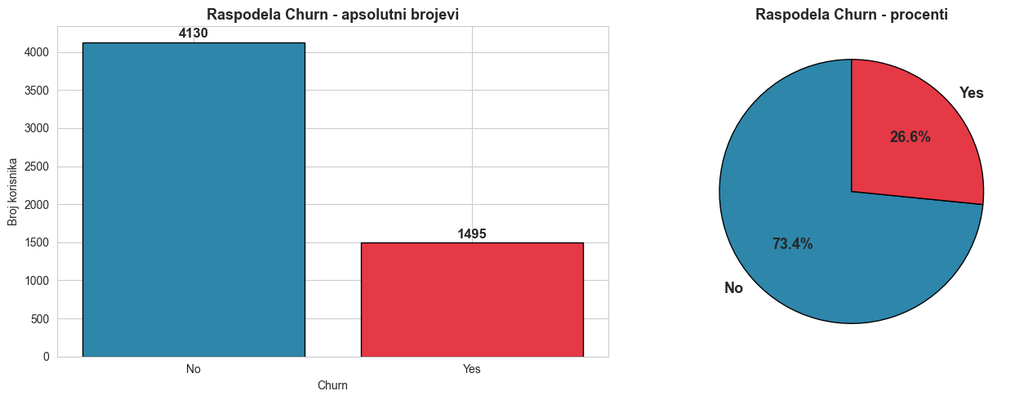

```
Odnos klasa: 1 napustio : 2.76 ostalih
```

```python
# Broj i procenat po klasi.
churn_counts = df_train["Churn"].value_counts()
churn_percent = df_train["Churn"].value_counts(normalize=True) * 100

fig, axes = plt.subplots(1, 2, figsize=(14, 5))

colors = ["#2E86AB", "#E63946"]

bars = axes[0].bar(churn_counts.index, churn_counts.values, color=colors, edgecolor="black")
axes[0].set_title("Raspodela Churn - apsolutni brojevi", fontsize=13, fontweight="bold")
axes[0].set_xlabel("Churn")
axes[0].set_ylabel("Broj korisnika")
for bar in bars:
    height = bar.get_height()
    axes[0].text(bar.get_x() + bar.get_width()/2., height + 30,
                 f'{int(height)}', ha='center', va='bottom', fontsize=12, fontweight="bold")

axes[1].pie(churn_counts.values, labels=churn_counts.index, colors=colors,
            autopct='%1.1f%%', startangle=90,
            textprops={'fontsize': 13, 'fontweight': 'bold'},
            wedgeprops={'edgecolor': 'black'})
axes[1].set_title("Raspodela Churn - procenti", fontsize=13, fontweight="bold")

plt.tight_layout()
plt.savefig("../images/06_churn_distribution.png", dpi=100, bbox_inches="tight")
plt.show()

print(f"\nOdnos klasa: 1 napustio : {churn_counts['No']/churn_counts['Yes']:.2f} ostalih")
```

### Tumačenje

Trening skup je nebalansiran: oko 73% korisnika je ostalo, a oko 27% je otišlo.

Ovaj odnos je bitan za dalju izgradnju modela, jer model lako može da "favorizuje" većinsku klasu. Zato ćemo pri evaluaciji gledati više metrika, ne samo accuracy, već i precision, recall, F1-score i ROC-AUC.

Poslovno gledano, otprilike svaki četvrti korisnik napušta kompaniju, što je dovoljno veliki problem da opravda razvoj prediktivnog modela.

## 3. Bivarijantna analiza: numeričke promenljive vs `Churn`

Za `tenure`, `MonthlyCharges` i `TotalCharges` radimo dve stvari:

1. Vizuelno: box-plot vrednosti po klasama `Churn`
2. Statistički: Mann-Whitney U test

Zašto baš Mann-Whitney, a ne t-test? Zato što t-test pretpostavlja normalnu raspodelu, a iz sveske `04` znamo da naše numeričke kolone imaju bimodalne ili iskošene raspodele, dakle nisu normalne. Mann-Whitney je neparametarski test i ne traži tu pretpostavku.

Hipoteze:

- H0 (nulta): raspodele su iste u obe klase, atribut ne razlikuje churn
- H1 (alternativna): raspodele se razlikuju, atribut utiče na churn

Ako je p-value < 0.05, odbacujemo H₀ i kažemo da postoji statistički značajna razlika.

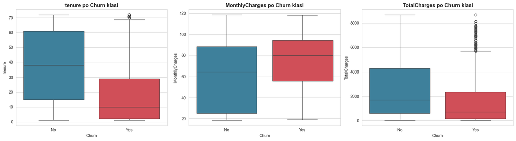

```python
# Definicija numeričkih kolona.
numericke_kolone = ["tenure", "MonthlyCharges", "TotalCharges"]

# Kreiramo figuru sa 3 grafika (jedan za svaku kolonu).
fig, axes = plt.subplots(1, 3, figsize=(18, 5))

for i, kolona in enumerate(numericke_kolone):
    sns.boxplot(data=df_train, x="Churn", y=kolona, ax=axes[i],
                palette={"No": "#2E86AB", "Yes": "#E63946"})
    axes[i].set_title(f"{kolona} po Churn klasi", fontsize=13, fontweight="bold")

plt.tight_layout()
plt.savefig("../images/06_numeric_vs_churn.png", dpi=100, bbox_inches="tight")
plt.show()
```

```python
# Statistički testovi: Mann-Whitney U za svaku numeričku kolonu.
print("=" * 70)
print("MANN-WHITNEY U TEST: NUMERIČKE PROMENLJIVE vs CHURN")
print("=" * 70)
print(f"{'Kolona':<20} {'U statistika':<15} {'p-value':<15} {'Značajno?':<10}")
print("-" * 70)

rezultati_numericki = {}

for kolona in numericke_kolone:
    # Razdvajamo vrednosti po klasi.
    grupa_no = df_train[df_train["Churn"] == "No"][kolona]
    grupa_yes = df_train[df_train["Churn"] == "Yes"][kolona]

    # Mann-Whitney U test.
    u_stat, p_value = stats.mannwhitneyu(grupa_no, grupa_yes, alternative="two-sided")

    znacajno = "DA" if p_value < 0.05 else "NE"
    print(f"{kolona:<20} {u_stat:<15.2f} {p_value:<15.5g} {znacajno:<10}")

    rezultati_numericki[kolona] = {"u_stat": u_stat, "p_value": p_value}
```

```
======================================================================
MANN-WHITNEY U TEST: NUMERIČKE PROMENLJIVE vs CHURN
======================================================================
Kolona               U statistika    p-value         Značajno?
----------------------------------------------------------------------
tenure               4569642.50      2.7332e-167     DA
MonthlyCharges       2339746.00      7.0793e-44      DA
TotalCharges         4019344.50      3.0122e-67      DA
```

### Tumačenje: numeričke promenljive

Ono što smo i očekivali, test to potvrđuje:

- `tenure`: korisnici koji odlaze imaju kraći staž od onih koji ostaju, što ima smisla, jer korisnici koji su duže u kompaniji ređe odlaze. Ovo je snažan prediktor.
- `MonthlyCharges`: korisnici koji odlaze plaćaju više mesečno. Skuplji paketi znače i veći rizik od odlaska, dakle značajan prediktor.
- `TotalCharges`: korisnici koji odlaze imaju manji ukupan iznos naplate, što je logično jer su kraće u kompaniji pa se manje nakupilo. Ovo je zapravo posledica `tenure`, i nije iznenađenje.

Kod sva tri Mann-Whitney testa p-value je ispod 0.05, što znači da sve tri kolone stvarno prave razliku između korisnika koji odlaze i onih koji ostaju.

## 4. Bivarijantna analiza: kategorijske promenljive vs `Churn`

Za kategorijske kolone radimo slično:

1. Vizuelno: bar plot proporcije Churn po kategorijama
2. Statistički: Hi kvadrat test nezavisnosti

Zašto baš Hi kvadrat test? To je standardni test kojim se proverava da li su dve kategorijske promenljive povezane, odnosno da li se frekvencije kombinacija razlikuju od onoga što bi očekivali da su promenljive nezavisne.

Hipoteze:

- H₀: kategorijska promenljiva i `Churn` su nezavisne, atribut ne utiče
- H₁: postoji zavisnost, atribut utiče na churn

Ako je p-value < 0.05, odbacujemo H₀, jer to znači da postoji statistički značajna zavisnost.

```python
# Definišemo koje kolone su kategorijske (sve osim numeričkih i Churn).
kategorijske_kolone = [k for k in df_train.columns
                        if k not in numericke_kolone and k != "Churn"]

# Hi kvadrat test za svaku kategorijsku kolonu.
print("=" * 70)
print("HI KVADRAT TEST: KATEGORIJSKE PROMENLJIVE vs CHURN")
print("=" * 70)
print(f"{'Kolona':<25} {'chi2':<12} {'p-value':<15} {'Značajno?':<10}")
print("-" * 70)

rezultati_kategorijski = {}

for kolona in kategorijske_kolone:
    # Contingency table (unakrsna tabela) - frekvencije kombinacija.
    contingency = pd.crosstab(df_train[kolona], df_train["Churn"])

    # hi kvadrat test.
    hi2, p_value, dof, expected = stats.chi2_contingency(contingency)

    znacajno = "DA" if p_value < 0.05 else "NE"
    print(f"{kolona:<25} {hi2:<12.2f} {p_value:<15.5g} {znacajno:<10}")

    rezultati_kategorijski[kolona] = {"hi2": hi2, "p_value": p_value}
```

```
======================================================================
HI KVADRAT TEST: KATEGORIJSKE PROMENLJIVE vs CHURN
======================================================================
Kolona                    chi2         p-value         Značajno?
----------------------------------------------------------------------
gender                    0.17         0.68186         NE
SeniorCitizen             127.28       1.6141e-29      DA
Partner                   133.23       8.0339e-31      DA
Dependents                163.98       1.5298e-37      DA
PhoneService              0.42         0.5171          NE
MultipleLines             10.98        0.0041208       DA
InternetService           579.94       1.1657e-126     DA
OnlineSecurity            688.13       3.7491e-150     DA
OnlineBackup              489.00       6.5174e-107     DA
DeviceProtection          439.78       3.1908e-96      DA
TechSupport               661.78       1.9751e-144     DA
StreamingTV               294.18       1.3185e-64      DA
StreamingMovies           296.84       3.4824e-65      DA
Contract                  972.62       6.279e-212      DA
PaperlessBilling          199.03       3.4034e-45      DA
PaymentMethod             529.90       1.5785e-114     DA
```

### Tumačenje: koje kategorijske promenljive su značajne

Kolone sa p < 0.05 imaju stvaran uticaj na verovatnoću churn-a, i njih vredi pažljivije pogledati na grafikonima. One kod kojih je p ≥ 0.05 ne pokazuju jasnu vezu sa churn-om, pa su kandidati da se izbace iz modela.

Konkretno, `gender` i `PhoneService` se pokazuju kao nevažni, dok su `Contract`, `InternetService`, `OnlineSecurity` i `TechSupport` među najznačajnijim prediktorima.

### 4.1 Vizualizacija najznačajnijih kategorijskih prediktora

Da bismo videli kako pojedine kategorije utiču na churn, prikazujemo bar plotove za nekoliko najvažnijih kolona.

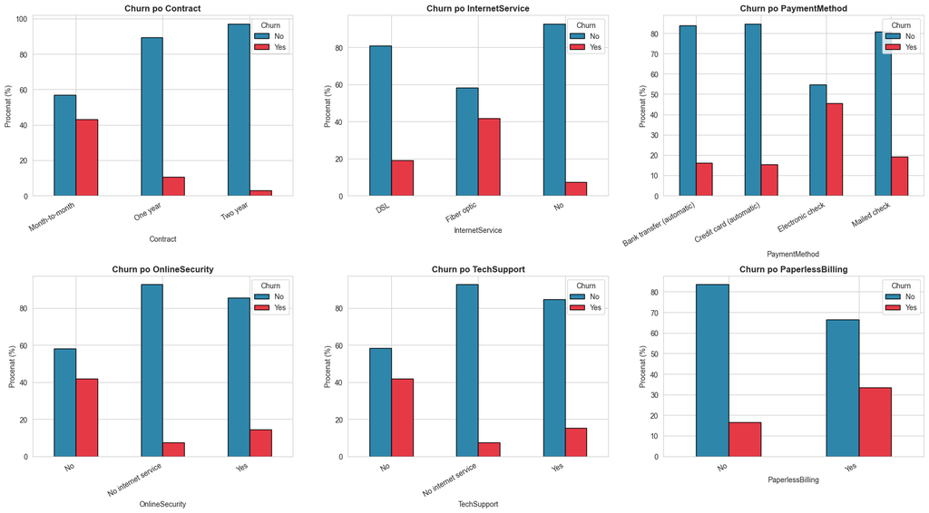

```python
# Biramo 6 kolona za detaljnu vizualizaciju (jedne od najznačajnijih).
kolone_za_vizualizaciju = ["Contract", "InternetService", "PaymentMethod",
                            "OnlineSecurity", "TechSupport", "PaperlessBilling"]

fig, axes = plt.subplots(2, 3, figsize=(18, 10))

for i, kolona in enumerate(kolone_za_vizualizaciju):
    ax = axes[i // 3, i % 3]

    # Proporcija Churn po kategorijama.
    ct = pd.crosstab(df_train[kolona], df_train["Churn"], normalize="index") * 100

    ct.plot(kind="bar", stacked=False, ax=ax,
            color=["#2E86AB", "#E63946"], edgecolor="black")
    ax.set_title(f"Churn po {kolona}", fontsize=12, fontweight="bold")
    ax.set_ylabel("Procenat (%)")
    ax.set_xlabel(kolona)
    ax.legend(title="Churn", loc="upper right")
    ax.set_xticklabels(ax.get_xticklabels(), rotation=30, ha="right")

plt.tight_layout()
plt.savefig("../images/06_categorical_vs_churn.png", dpi=100, bbox_inches="tight")
plt.show()
```

### Tumačenje: ključni obrasci

Iz ovih grafikona izdvajamo nekoliko obrazaca koji se ponavljaju:

`Contract` se pokazuje kao najsnažniji prediktor. Korisnici sa `Month-to-month` ugovorom odlaze mnogo češće (churn oko 43%), kod `One year` je to umereno (oko 11%), a kod `Two year` gotovo da i nema odlazaka (oko 3%). Logika je jednostavna, što je ugovor duži, to je korisnik lojalniji.

Kod `InternetService` situacija je pomalo neočekivana: korisnici sa `Fiber optic` internetom imaju najveći churn (oko 42%), `DSL` korisnici umeren (oko 19%), a oni bez interneta najmanji (oko 7%). Čovek bi očekivao da brži internet znači zadovoljnijeg i lojalnijeg korisnika, pa ovo vredi dalje istražiti, možda je razlog cena ili kvalitet usluge.

Kod `PaymentMethod`, korisnici koji plaćaju preko `Electronic check` imaju daleko najveći churn (oko 45%), dok su ostali načini plaćanja znatno niži (oko 15-19%). Moguće objašnjenje je da je `Electronic check` najmanje automatizovan način plaćanja, pa su ti korisnici manje "vezani" za kompaniju.

Kod `OnlineSecurity` i `TechSupport` vidimo da korisnici koji NEMAJU ove usluge odlaze znatno češće. Deluje kao da ove dodatne usluge rade kao neka vrsta "sidra" koje zadržava korisnika.

Kod `PaperlessBilling`, korisnici koji su izabrali `Yes` imaju veći churn, što bi moglo biti povezano s tim da su to mlađi, "digitalniji" korisnici koji su generalno manje lojalni.

## 5. Provera normalnosti numeričkih kolona

Radi potpunosti analize, formalno proveravamo normalnost numeričkih kolona pomoću Shapiro-Wilk testa. Ovim zapravo dokumentujemo zašto smo ranije koristili Mann-Whitney U test umesto t-testa.

Hipoteze:

- H₀: podaci potiču iz normalne raspodele
- H₁: podaci NE potiču iz normalne raspodele

Ako je p-value < 0.05, odbacujemo H₀, što znači da podaci nisu normalno raspoređeni.

Da napomenemo, Shapiro-Wilk test se preporučuje za manje uzorke (ispod 5000). Kako naš skup ima 5625 redova, uzimamo slučajan uzorak od 5000 redova da bi test bio tačan.

```python
# Shapiro-Wilk test za normalnost.
print("=" * 70)
print("SHAPIRO-WILK TEST NORMALNOSTI")
print("=" * 70)
print(f"{'Kolona':<20} {'W statistika':<15} {'p-value':<15} {'Normalno?':<10}")
print("-" * 70)

# Slučajan uzorak od 5000 redova (za tačnost Shapiro testa).
uzorak = df_train.sample(n=5000, random_state=42)

for kolona in numericke_kolone:
    w_stat, p_value = stats.shapiro(uzorak[kolona])
    normalno = "DA" if p_value >= 0.05 else "NE"
    print(f"{kolona:<20} {w_stat:<15.5f} {p_value:<15.5g} {normalno:<10}")

print("\nRezultat: sve numeričke kolone NISU normalno raspoređene (p < 0.05).")
print("Ovo opravdava izbor neparametarskog Mann-Whitney U testa umesto t-testa.")
```

```
======================================================================
SHAPIRO-WILK TEST NORMALNOSTI
======================================================================
Kolona               W statistika    p-value         Normalno?
----------------------------------------------------------------------
tenure               0.90417         1.7015e-48      NE
MonthlyCharges       0.92054         2.0228e-45      NE
TotalCharges         0.86086         6.2487e-55      NE

Rezultat: sve numeričke kolone NISU normalno raspoređene (p < 0.05).
Ovo opravdava izbor neparametarskog Mann-Whitney U testa umesto t-testa.
```

## 6. Analiza korelacija između numeričkih promenljivih

Ovde proveravamo ima li kolinearnosti između numeričkih atributa, jer je to bitno za linearne modele, previše korelisani prediktori im mogu praviti probleme.

Koristimo Spearman korelaciju, neparametarsku verziju Pearson-a, jer naši podaci nisu normalno raspoređeni.

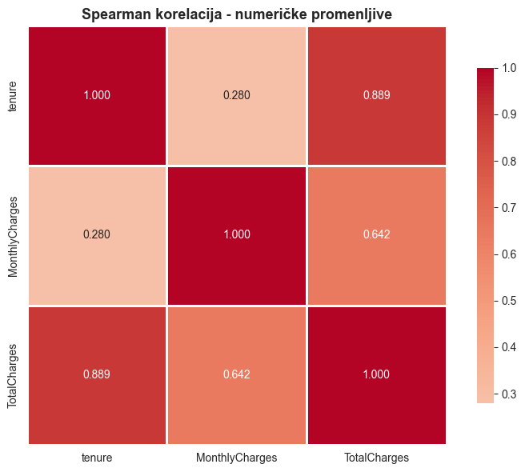

```
Korelaciona matrica:
                tenure  MonthlyCharges  TotalCharges
tenure           1.000           0.280         0.889
MonthlyCharges   0.280           1.000         0.642
TotalCharges     0.889           0.642         1.000
```

```python
# Spearman korelacija numeričkih kolona.
corr_matrix = df_train[numericke_kolone].corr(method="spearman")

# Vizualizacija kao heatmap.
plt.figure(figsize=(8, 6))
sns.heatmap(corr_matrix, annot=True, cmap="coolwarm", center=0,
            fmt=".3f", square=True, linewidths=1, cbar_kws={"shrink": 0.8})
plt.title("Spearman korelacija - numeričke promenljive", fontsize=13, fontweight="bold")
plt.tight_layout()
plt.savefig("../images/06_correlation_heatmap.png", dpi=100, bbox_inches="tight")
plt.show()

print("\nKorelaciona matrica:")
print(corr_matrix.round(3))
```

```python
from statsmodels.stats.outliers_influence import variance_inflation_factor

# TenureGroup pravimo lokalno samo za potrebe VIF analize.
# U svesci 05_priprema_podataka je već ova grupa dodata u X_train.csv (za modele),
# ali ovde je re-kreiramo jer sveska 06 radi sa data/processed/ (pre enkodiranja).
df_train["TenureGroup"] = pd.cut(
    df_train["tenure"],
    bins=[0, 12, 24, 48, 100],
    labels=[0, 1, 2, 3],   # već ordinalno, spremno za VIF
    include_lowest=True
).astype(int)

print("TenureGroup dodat za VIF analizu:")
print(df_train["TenureGroup"].value_counts().sort_index())
X_numeric = df_train[["tenure", "MonthlyCharges", "TotalCharges", "TenureGroup"]].copy()

vif_data = pd.DataFrame()
vif_data["Kolona"] = X_numeric.columns
vif_data["VIF"] = [variance_inflation_factor(X_numeric.values, i)
                   for i in range(X_numeric.shape[1])]

print("VIF vrednosti za numeričke promenljive:")
print(vif_data.to_string(index=False))
```

```
TenureGroup dodat za VIF analizu:
TenureGroup
0    1724
1     818
2    1279
3    1804
Name: count, dtype: int64
VIF vrednosti za numeričke promenljive:
        Kolona       VIF
        tenure 41.506982
MonthlyCharges  3.391171
  TotalCharges  8.219885
   TenureGroup 34.056893
```

### Interpretacija VIF vrednosti i odluka

**Dobijene VIF vrednosti:**

| Kolona | VIF |
| --- | --- |
| `tenure` | 41.5 |
| `MonthlyCharges` | ~3.4 |
| `TotalCharges` | ~8.2 |
| `TenureGroup` | 34 |

Kao što je i očekivano, `tenure` i `TenureGroup` imaju izuzetno visok VIF jer je `TenureGroup` direktno izveden iz `tenure` (`pd.cut`). Oni nose gotovo istu informaciju.

`TotalCharges` je u zoni umerene multikolinearnosti (VIF 8-9), zbog jake veze sa `tenure` (~0.89 korelacija).

**Šta radimo dalje:**

Kod **Logističke regresije** izbacićemo **dve kolone** pre treniranja:

- `TotalCharges` — visoko korelisan sa `tenure`
- `TenureGroup` — savršeno kolinearan sa `tenure`

Zadržavamo `tenure` (poslovno najinterpretabilnije) i `MonthlyCharges` (nezavisna informacija o skupoći paketa).

Kod **modela na stablima** (Random Forest, XGBoost) zadržavamo sve kolone, multikolinearnost im ne smeta.

Sam kod za izbacivanje biće u notebook-u `07_modeliranje_i_evaluacija`.

## 7. Rezime statističke značajnosti: koji atributi su prediktori?

Da bismo lakše sagledali rezultate svih testova, sumiramo ih ovde u jednu tabelu.

```python
# Kombinujemo rezultate numeričkih (Mann-Whitney) i kategorijskih (hi-kvadrat) testova.
print("=" * 70)
print("REZIME STATISTIČKE ZNAČAJNOSTI SVIH PREDIKTORA")
print("=" * 70)

rezime = []

for kolona, res in rezultati_numericki.items():
    rezime.append({
        "Kolona": kolona,
        "Tip": "numerička",
        "Test": "Mann-Whitney U",
        "p-value": res["p_value"],
        "Značajno (alfa=0.05)": "DA" if res["p_value"] < 0.05 else "NE"
    })

for kolona, res in rezultati_kategorijski.items():
    rezime.append({
        "Kolona": kolona,
        "Tip": "kategorijska",
        "Test": "hi-kvadrat",
        "p-value": res["p_value"],
        "Značajno (alfa=0.05)": "DA" if res["p_value"] < 0.05 else "NE"
    })

rezime_df = pd.DataFrame(rezime).sort_values("p-value").reset_index(drop=True)

# Formatiramo p-value za bolji prikaz.
rezime_df["p-value"] = rezime_df["p-value"].apply(lambda x: f"{x:.5g}")

print(rezime_df.to_string(index=False))

# Broj značajnih i neznačajnih.
znacajni = sum(1 for r in rezime if r["Značajno (alfa=0.05)"] == "DA")
neznacajni = len(rezime) - znacajni
print(f"\nUkupno atributa: {len(rezime)}")
print(f"  Statistički značajni prediktori: {znacajni}")
print(f"  Neznačajni: {neznacajni}")
```

```
======================================================================
REZIME STATISTIČKE ZNAČAJNOSTI SVIH PREDIKTORA
======================================================================
          Kolona          Tip           Test     p-value Značajno (alfa=0.05)
        Contract kategorijska     hi-kvadrat  6.279e-212                   DA
          tenure    numerička Mann-Whitney U 2.7332e-167                   DA
  OnlineSecurity kategorijska     hi-kvadrat 3.7491e-150                   DA
     TechSupport kategorijska     hi-kvadrat 1.9751e-144                   DA
 InternetService kategorijska     hi-kvadrat 1.1657e-126                   DA
   PaymentMethod kategorijska     hi-kvadrat 1.5785e-114                   DA
    OnlineBackup kategorijska     hi-kvadrat 6.5174e-107                   DA
DeviceProtection kategorijska     hi-kvadrat  3.1908e-96                   DA
    TotalCharges    numerička Mann-Whitney U  3.0122e-67                   DA
 StreamingMovies kategorijska     hi-kvadrat  3.4824e-65                   DA
     StreamingTV kategorijska     hi-kvadrat  1.3185e-64                   DA
PaperlessBilling kategorijska     hi-kvadrat  3.4034e-45                   DA
  MonthlyCharges    numerička Mann-Whitney U  7.0793e-44                   DA
      Dependents kategorijska     hi-kvadrat  1.5298e-37                   DA
         Partner kategorijska     hi-kvadrat  8.0339e-31                   DA
   SeniorCitizen kategorijska     hi-kvadrat  1.6141e-29                   DA
   MultipleLines kategorijska     hi-kvadrat   0.0041208                   DA
    PhoneService kategorijska     hi-kvadrat      0.5171                   NE
          gender kategorijska     hi-kvadrat     0.68186                   NE

Ukupno atributa: 19
  Statistički značajni prediktori: 17
  Neznačajni: 2
```

### Tumačenje rezimea

Prediktori sa p < 0.05 su oni koji stvarno utiču na verovatnoću churn-a, i od njih očekujemo da modeli nauče najviše.

Oni sa p ≥ 0.05, najčešće `gender` i `PhoneService`, kandidati su za izbacivanje. Da ih izbacimo verovatno ne bi mnogo promenilo model, a smanjilo bi broj dimenzija.

Ipak, u ovom projektu smo se odlučili da zadržimo sve prediktore u prvim modelima, i da pustimo modele same da pokažu šta im je nevažno, kroz `feature_importance_` kod Random Forest-a i XGBoost-a, ili kroz koeficijente kod Logističke regresije. Ako se pokaže da su neki modeli previše kompleksni, izbacivanje neznačajnih atributa ostaje opcija za kasniju optimizaciju.

## 8. Zaključak

Kroz ovu iterativnu analizu smo došli do nekoliko važnih zaključaka.

Pre svega, ciljna promenljiva je nebalansirana (oko 73% No, 27% Yes), što direktno utiče na to koje metrike i strategije modeliranja treba koristiti dalje.

Kad je reč o prediktorima, ubedljivo najjači je `Contract`: korisnici sa `Month-to-month` ugovorom odlaze u oko 43% slučajeva, dok kod `Two year` ugovora to je svega oko 3%. Pored njega, kraći `tenure` znači veću šansu da korisnik ode, a slično važi i za `InternetService`, gde `Fiber optic` korisnici imaju najveći churn (oko 42%). `PaymentMethod` takođe pravi razliku, korisnici koji plaćaju preko `Electronic check`-a napuštaju znatno češće od ostalih. Nedostatak usluga `OnlineSecurity` i `TechSupport` takođe povećava churn, kao i viši `MonthlyCharges`.

S druge strane, `gender` i `PhoneService` ispadaju statistički neznačajni (p > 0.05), što i ima smisla, ova dva atributa ne govore ništa o tome kako korisnik zapravo koristi uslugu.

Primetili smo i snažnu korelaciju između `tenure` i `TotalCharges` (oko 0.9+), što je nešto na šta treba paziti kod linearnih modela zbog mogućeg problema multikolinearnosti.

Na metodološkom nivou, Shapiro-Wilk test je potvrdio da numeričke kolone nisu normalno raspoređene, zbog čega smo koristili Mann-Whitney U test umesto t-testa, dok smo za sve kategorijske promenljive naspram `Churn` koristili Hi-kvadrat test.

Ako sve ovo prevedemo u poslovni jezik, korisnik sa najvećim rizikom od odlaska je onaj koji je tek stigao, ima Month-to-month ugovor, Fiber optic internet, plaća preko Electronic check-a i nema dodatne usluge. Baš na takve korisnike bi trebalo usmeriti mere zadržavanja.

# 07 - Modeliranje i evaluacija

U ovoj svesci koristimo podatke pripremljene u prethodnim fazama projekta da izgradimo i ocenimo nekoliko modela mašinskog učenja.

Cilj nam je model koji na osnovu karakteristika korisnika i usluga koje koristi predviđa da li će napustiti kompaniju (`Churn`).

Isprobaćemo tri različita algoritma, da bismo mogli da ih uporedimo međusobno:

- Logistička regresija, jednostavan i lako razumljiv linearni model
- Random Forest, ansambl više stabala odlučivanja
- XGBoost, napredniji ansambl model zasnovan na gradijentnom boostingu

Kad je reč o evaluaciji, nećemo se osloniti samo na accuracy, već ćemo pratiti i:

- Precision
- Recall
- F1-score
- ROC-AUC

Recall i F1-score nam posebno znače u ovom slučaju, s obzirom na to da je `Churn` nebalansirana promenljiva.

## 1. Učitavanje pripremljenih podataka

Učitavamo podatke pripremljene u svesci `05`, iz foldera `data/ml/`, koji su već očišćeni, transformisani, enkodirani i potpuno numerički.

Kao i do sada, koristimo odvojene trening i test skupove. Model treniramo isključivo na trening skupu, a test skup čuvamo za samu evaluaciju na kraju.

```python
import pandas as pd
import numpy as np

pd.set_option("display.max_columns", None)

putanja_ml = "../data/ml/"

X_train = pd.read_csv(putanja_ml + "X_train.csv")
X_test = pd.read_csv(putanja_ml + "X_test.csv")
y_train = pd.read_csv(putanja_ml + "y_train.csv").squeeze()
y_test = pd.read_csv(putanja_ml + "y_test.csv").squeeze()

print("Podaci uspešno učitani:")
print(f"X_train: {X_train.shape[0]} redova x {X_train.shape[1]} kolona")
print(f"X_test:  {X_test.shape[0]} redova x {X_test.shape[1]} kolona")
print(f"y_train: {y_train.shape[0]} vrednosti")
print(f"y_test:  {y_test.shape[0]} vrednosti")
```

```
Podaci uspešno učitani:
X_train: 5625 redova x 25 kolona
X_test:  1407 redova x 25 kolona
y_train: 5625 vrednosti
y_test:  1407 vrednosti
```

### 1.1 Provera strukture podataka

Pre nego što krenemo sa treniranjem, proveravamo da su trening i test skup pravilno učitani i da imaju isti broj prediktora.

```python
print("Broj kolona:")
print(f"X_train: {X_train.shape[1]}")
print(f"X_test:  {X_test.shape[1]}")

print("\nRaspodela ciljnih klasa:")
print("y_train:")
print(y_train.value_counts())

print("\ny_test:")
print(y_test.value_counts())

print("\nNedostajuće vrednosti:")
print(f"X_train NaN: {X_train.isnull().sum().sum()}")
print(f"X_test NaN:  {X_test.isnull().sum().sum()}")
print(f"y_train NaN: {y_train.isnull().sum()}")
print(f"y_test NaN:  {y_test.isnull().sum()}")
```

```
Broj kolona:
X_train: 25
X_test:  25

Raspodela ciljnih klasa:
y_train:
Churn
0    4130
1    1495
Name: count, dtype: int64

y_test:
Churn
0    1033
1     374
Name: count, dtype: int64

Nedostajuće vrednosti:
X_train NaN: 0
X_test NaN:  0
y_train NaN: 0
y_test NaN:  0
```

## 2. Logistička regresija

Logistička regresija je osnovni model za binarnu klasifikaciju, pa je koristimo za predviđanje da li će korisnik napustiti kompaniju (`Churn = 1`) ili ostati (`Churn = 0`).

Prednost ovog modela je što je jednostavan i lako razumljiv, pa nam služi kao dobra polazna tačka za poređenje sa složenijim modelima kasnije.

Kako je ciljna promenljiva nebalansirana, koristimo `class_weight="balanced"`, čime dajemo veću težinu manjinskoj klasi (`Churn = 1`).

### 2.1 Definisanje modela

Kao što je već rečeno, logistička regresija rešava binarnu klasifikaciju, u našem slučaju predviđanje da li korisnik napušta kompaniju (`Churn = 1`) ili ostaje (`Churn = 0`).

Kako promenljive imaju različite opsege vrednosti, prvo standardizujemo numeričke karakteristike. Ovo modelu olakšava da pronađe optimalne parametre i pomaže algoritmu da brže konvergira.

Klase su nebalansirane, pa opet koristimo `class_weight="balanced"`, da bi model obratio više pažnje na manjinsku klasu (`Churn = 1`).

```python
from sklearn.linear_model import LogisticRegression
from sklearn.preprocessing import StandardScaler

# Za linearne modele izbacujemo TotalCharges i TenureGroup zbog multikolinearnosti sa tenure.
X_train_linear = X_train.drop(columns=["TotalCharges", "TenureGroup"])
X_test_linear = X_test.drop(columns=["TotalCharges", "TenureGroup"])
# Standardizacija se primenjuje na verziju bez TotalCharges.
scaler = StandardScaler()
X_train_scaled = scaler.fit_transform(X_train_linear)
X_test_scaled = scaler.transform(X_test_linear)
print(f"Broj kolona nakon izbacivanja: {X_train_linear.shape[1]}")

# Definisanje logističke regresije.
model_logreg = LogisticRegression(
    max_iter=1000,
    class_weight="balanced",
    random_state=42
)

print("Logistička regresija je uspešno definisana.")
```

```
Broj kolona nakon izbacivanja: 23
Logistička regresija je uspešno definisana.
```

### 2.2 Treniranje modela

Model treniramo isključivo na trening skupu (`X_train` i `y_train`), dok test skup u ovoj fazi uopšte ne diramo, da bi ostao nezavisan za konačnu evaluaciju.

Kroz treniranje model zapravo uči kakav je odnos između karakteristika korisnika i toga da li on napušta kompaniju.

```python
model_logreg.fit(X_train_scaled, y_train)

print("Logistička regresija je uspešno istrenirana.")
```

```
Logistička regresija je uspešno istrenirana.
```

### 2.3 Predikcija

Sad kad je model istreniran, koristimo ga da nad test skupom (`X_test`) predvidimo kojoj klasi svaki korisnik pripada:

- `0`: korisnik ostaje
- `1`: korisnik napušta kompaniju

Ovo je prvi put da uopšte diramo test skup, tako da su predikcije koje dobijamo potpuno nezavisne i spremne za evaluaciju.

```python
y_pred_logreg = model_logreg.predict(X_test_scaled)

print("Predikcija završena.")
print(f"Broj predikcija: {len(y_pred_logreg)}")
```

```
Predikcija završena.
Broj predikcija: 1407
```

### 2.4 Raspodela predviđenih klasa

Pogledajmo koliko je korisnika model svrstao u klasu `0`, a koliko u klasu `1`, i uporedimo to sa stvarnom raspodelom klasa u test skupu.

```python
print("Predviđena raspodela klasa:")
print(pd.Series(y_pred_logreg).value_counts().sort_index())

print("\nStvarna raspodela klasa:")
print(y_test.value_counts().sort_index())
```

```
Predviđena raspodela klasa:
0    811
1    596
Name: count, dtype: int64

Stvarna raspodela klasa:
Churn
0    1033
1     374
Name: count, dtype: int64
```

### 2.5 Evaluacija logističke regresije

Sad kad imamo predikcije, vidimo kako se model pokazao kroz nekoliko metrika:

- **Accuracy**: procenat svih tačno klasifikovanih korisnika
- **Precision**: od svih korisnika koje je model označio kao one koji odlaze, koliko ih je stvarno otišlo
- **Recall**: od svih korisnika koji su zaista otišli, koliko je model uspeo da prepozna
- **F1-score**: harmonijska sredina Precision i Recall
- **ROC-AUC**: koliko dobro model uopšte razlikuje one koji odlaze od onih koji ostaju

Nama je ovde posebno bitan Recall za klasu 1, jer želimo da uhvatimo što veći broj korisnika koji stvarno napuštaju kompaniju.

```python
from sklearn.metrics import (
    accuracy_score,
    precision_score,
    recall_score,
    f1_score,
    roc_auc_score
)

accuracy_logreg = accuracy_score(y_test, y_pred_logreg)
precision_logreg = precision_score(y_test, y_pred_logreg)
recall_logreg = recall_score(y_test, y_pred_logreg)
f1_logreg = f1_score(y_test, y_pred_logreg)

# Verovatnoća pripadnosti klasi 1.
y_prob_logreg = model_logreg.predict_proba(X_test_scaled)[:, 1]

roc_auc_logreg = roc_auc_score(y_test, y_prob_logreg)

print("=" * 50)
print("EVALUACIJA LOGISTIČKE REGRESIJE")
print("=" * 50)
print(f"Accuracy:  {accuracy_logreg:.4f}")
print(f"Precision: {precision_logreg:.4f}")
print(f"Recall:    {recall_logreg:.4f}")
print(f"F1-score:  {f1_logreg:.4f}")
print(f"ROC-AUC:   {roc_auc_logreg:.4f}")
```

```
==================================================
EVALUACIJA LOGISTIČKE REGRESIJE
==================================================
Accuracy:  0.7271
Precision: 0.4916
Recall:    0.7834
F1-score:  0.6041
ROC-AUC:   0.8328
```

### Poređenje sa prethodnom verzijom modela

Pre nego što smo primenili nalaz iz VIF analize (svеska `06`), Logistička regresija je trenirana na svih 25 atributa, uključujući `TotalCharges` i `TenureGroup`. Sada, nakon izbacivanja te dve kolone, dobijamo sledeće:

| Metrika | Pre | Posle |
| --- | --- | --- |
| Accuracy | 0.7242 | 0.7271 |
| Precision | 0.4884 | 0.4916 |
| Recall | 0.7888 | 0.7834 |
| F1-score | 0.6033 | 0.6041 |
| ROC-AUC | 0.8342 | 0.8328 |

### 2.6 Matrica konfuzije

Matrica konfuzije prikazuje broj tačno i netačno klasifikovanih korisnika.

Kod našeg problema imamo četiri slučaja:

- **True Negative (TN)** — korisnik je ostao i model je to pravilno predvideo
- **False Positive (FP)** — korisnik je ostao, ali je model predvideo da će otići
- **False Negative (FN)** — korisnik je otišao, ali model to nije prepoznao
- **True Positive (TP)** — korisnik je otišao i model je to pravilno predvideo

Posebno je važan broj **False Negative** slučajeva, jer oni predstavljaju korisnike koji će otići, a model ih nije prepoznao.

```
Matrica konfuzije:
[[730 303]
 [ 81 293]]
```

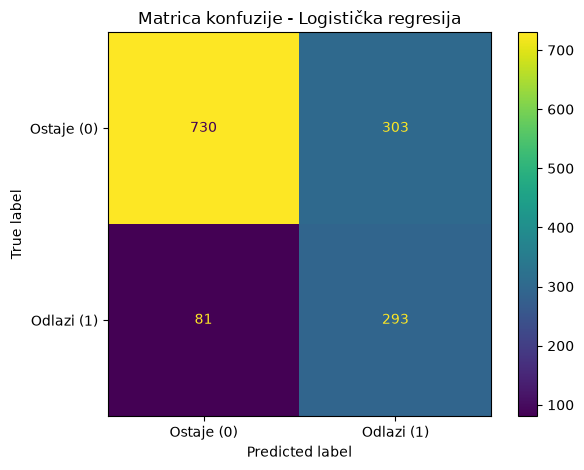

```python
import matplotlib.pyplot as plt
from sklearn.metrics import confusion_matrix, ConfusionMatrixDisplay

cm_logreg = confusion_matrix(y_test, y_pred_logreg)

print("Matrica konfuzije:")
print(cm_logreg)

disp = ConfusionMatrixDisplay(
    confusion_matrix=cm_logreg,
    display_labels=["Ostaje (0)", "Odlazi (1)"]
)

disp.plot()
plt.title("Matrica konfuzije - Logistička regresija")
plt.tight_layout()

plt.savefig(
    "../images/07_logreg_confusion_matrix.png",
    dpi=100,
    bbox_inches="tight"
)

plt.show()
```

### Tumačenje matrice konfuzije

Iz matrice konfuzije vidimo da je logistička regresija prepoznala većinu korisnika koji su zaista otišli (293 TP), dok je 81 njih (FN) propustila.

S druge strane, model je 303 korisnika (FP) označio kao rizične iako su oni na kraju ostali. Ovo je i očekivano, s obzirom na to da smo koristili `class_weight="balanced"`, čime smo model učinili osetljivijim na manjinsku klasu `Churn = 1`.

Sve u svemu, logistička regresija dobro prepoznaje korisnike koji odlaze (Recall od 78.34%), ali po cenu nešto više lažno pozitivnih predikcija.

## 3. Random Forest

Random Forest je ansambl metoda koja kombinuje veliki broj stabala odluke, svako sa svojim predikcijama, a konačna klasifikacija se dobija kombinovanjem tih rezultata.

Za razliku od logističke regresije, ovaj model može da uhvati složenije, nelinearne odnose između atributa, što je korisno kad uticaj neke karakteristike na `Churn` nije jednostavan i pravolinijski.

Kao i ranije, koristimo `class_weight="balanced"` da bismo uzeli u obzir nebalansirane klase.

### 3.1 Definisanje modela

```python
from sklearn.ensemble import RandomForestClassifier

model_rf = RandomForestClassifier(
    n_estimators=300,
    max_depth=None,
    min_samples_split=2,
    class_weight="balanced",
    random_state=42,
    n_jobs=-1
)

print("Random Forest je uspešno definisan.")
```

```
Random Forest je uspešno definisan.
```

### 3.2 Treniranje modela

Random Forest treniramo na trening skupu. Test skup ostaje odvojen i koristiće se tek nakon završetka treniranja za evaluaciju modela.

```python
model_rf.fit(X_train, y_train)

print("Random Forest je uspešno istreniran.")
```

```
Random Forest je uspešno istreniran.
```

### 3.3 Predikcija

Nakon treniranja, Random Forest predviđa klasu za svakog korisnika iz test skupa.

```python
y_pred_rf = model_rf.predict(X_test)

print("Predikcija završena.")
print(f"Broj predikcija: {len(y_pred_rf)}")
```

```
Predikcija završena.
Broj predikcija: 1407
```

### 3.4 Raspodela predviđenih klasa

Proveravamo raspodelu klasa koje je Random Forest predvideo i upoređujemo je sa stvarnom raspodelom klasa u test skupu.

```python
print("Predviđena raspodela klasa:")
print(pd.Series(y_pred_rf).value_counts().sort_index())

print("\nStvarna raspodela klasa:")
print(y_test.value_counts().sort_index())
```

```
Predviđena raspodela klasa:
0    962
1    445
Name: count, dtype: int64

Stvarna raspodela klasa:
Churn
0    1033
1     374
Name: count, dtype: int64
```

### 3.5 Evaluacija Random Forest-a

I Random Forest evaluiramo istim metrikama kao logističku regresiju, da bi poređenje bilo ravnopravno: Accuracy, Precision, Recall, F1-score i ROC-AUC.

Kao i ranije, Recall i F1-score nam ovde znače najviše, zbog nebalansiranih klasa.

```python
accuracy_rf = accuracy_score(y_test, y_pred_rf)
precision_rf = precision_score(y_test, y_pred_rf)
recall_rf = recall_score(y_test, y_pred_rf)
f1_rf = f1_score(y_test, y_pred_rf)

# Verovatnoća pripadnosti klasi 1.
y_prob_rf = model_rf.predict_proba(X_test)[:, 1]

roc_auc_rf = roc_auc_score(y_test, y_prob_rf)

print("=" * 50)
print("EVALUACIJA RANDOM FOREST-A")
print("=" * 50)
print(f"Accuracy:  {accuracy_rf:.4f}")
print(f"Precision: {precision_rf:.4f}")
print(f"Recall:    {recall_rf:.4f}")
print(f"F1-score:  {f1_rf:.4f}")
print(f"ROC-AUC:   {roc_auc_rf:.4f}")
```

```
==================================================
EVALUACIJA RANDOM FOREST-A
==================================================
Accuracy:  0.7676
Precision: 0.5528
Recall:    0.6578
F1-score:  0.6007
ROC-AUC:   0.8200
```

### 3.4 Matrica konfuzije

Matrica konfuzije prikazuje broj tačno i netačno klasifikovanih korisnika za Random Forest model.

Posebno pratimo **False Negative (FN)** slučajeve, odnosno korisnike koji su zaista napustili kompaniju, ali ih model nije prepoznao.

Kod problema churn-a cilj je da broj ovakvih slučajeva bude što manji.

```
Matrica konfuzije:
[[834 199]
 [128 246]]
```

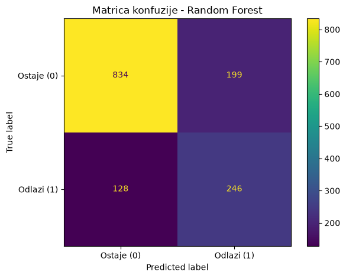

```python
import matplotlib.pyplot as plt
from sklearn.metrics import confusion_matrix, ConfusionMatrixDisplay

cm_rf = confusion_matrix(y_test, y_pred_rf)

print("Matrica konfuzije:")
print(cm_rf)

disp = ConfusionMatrixDisplay(
    confusion_matrix=cm_rf,
    display_labels=["Ostaje (0)", "Odlazi (1)"]
)

disp.plot()
plt.title("Matrica konfuzije - Random Forest")
plt.tight_layout()

plt.savefig(
    "../images/07_rf_confusion_matrix.png",
    dpi=100,
    bbox_inches="tight"
)

plt.show()
```

### Tumačenje matrice konfuzije

Random Forest je pravilno prepoznao 246 korisnika koji su zaista otišli (TP), dok mu je 128 takvih korisnika (FN) promaklo. Pored toga, 199 korisnika (FP) je označio kao rizične iako su na kraju ostali.

U poređenju sa logističkom regresijom, Random Forest bolje prepoznaje korisnike koji ostaju, ali zato propušta više stvarnih odlazaka, što se i vidi po nižem Recall-u (65.78% naspram 78.34% kod logističke regresije).

Iako Random Forest ima veću Accuracy, logistička regresija se ovde pokazala kao bolja u prepoznavanju korisnika koji odlaze, a to je za problem churn-a ono što nam je najbitnije.

## 4. XGBoost

XGBoost (Extreme Gradient Boosting) je napredni ansambl algoritam koji, za razliku od Random Forest-a, ne gradi stabla nezavisno, već ih dodaje jedno po jedno, tako da svako naredno stablo ispravlja greške prethodnih.

I ovaj model, kao i Random Forest, može da uhvati složenije, nelinearne odnose između atributa i ciljne promenljive, pa ga koristimo kao treći model za poređenje sa logističkom regresijom i Random Forest-om.

Kako je ciljna promenljiva nebalansirana, i ovde podešavamo težinu pozitivne klase (`Churn = 1`), ovog puta preko parametra `scale_pos_weight`.

### 4.1 Definisanje modela

Za XGBoost podešavamo nekoliko osnovnih parametara koji utiču na složenost modela i na sam proces učenja.

`n_estimators` govori koliko stabala model gradi, `max_depth` određuje njihovu maksimalnu dubinu, a `learning_rate` koliko jako svako novo stablo utiče na konačan rezultat.

Zbog nebalansiranih klasa, tu je i `scale_pos_weight`, kao i ranije.

```python
from xgboost import XGBClassifier

# Izračunavanje težine pozitivne klase.
broj_0 = (y_train == 0).sum()
broj_1 = (y_train == 1).sum()

scale_pos_weight = broj_0 / broj_1

print(f"Broj korisnika koji ostaju (0): {broj_0}")
print(f"Broj korisnika koji odlaze (1): {broj_1}")
print(f"scale_pos_weight: {scale_pos_weight:.2f}")

model_xgb = XGBClassifier(
    n_estimators=300,
    max_depth=4,
    learning_rate=0.05,
    subsample=0.8,
    colsample_bytree=0.8,
    scale_pos_weight=scale_pos_weight,
    random_state=42,
    eval_metric="logloss"
)

print("\nXGBoost je uspešno definisan.")
```

```
Broj korisnika koji ostaju (0): 4130
Broj korisnika koji odlaze (1): 1495
scale_pos_weight: 2.76

XGBoost je uspešno definisan.
```

### 4.2 Treniranje modela

XGBoost treniramo isključivo na trening skupu. Test skup se ne koristi tokom procesa učenja, već ostaje nezavisan za kasniju evaluaciju.

```python
model_xgb.fit(X_train, y_train)

print("XGBoost je uspešno istreniran.")
```

```
XGBoost je uspešno istreniran.
```

### 4.3 Predikcija

Nakon treniranja, XGBoost koristi karakteristike korisnika iz test skupa kako bi predvideo da li korisnik ostaje (`0`) ili napušta kompaniju (`1`).

```python
y_pred_xgb = model_xgb.predict(X_test)

print("Predikcija završena.")
print(f"Broj predikcija: {len(y_pred_xgb)}")
```

```
Predikcija završena.
Broj predikcija: 1407
```

### 4.4 Raspodela predviđenih klasa

Proveravamo raspodelu predviđenih klasa i upoređujemo je sa stvarnom raspodelom korisnika u test skupu.

```python
print("Predviđena raspodela klasa:")
print(pd.Series(y_pred_xgb).value_counts().sort_index())

print("\nStvarna raspodela klasa:")
print(y_test.value_counts().sort_index())
```

```
Predviđena raspodela klasa:
0    823
1    584
Name: count, dtype: int64

Stvarna raspodela klasa:
Churn
0    1033
1     374
Name: count, dtype: int64
```

### 4.5 Evaluacija XGBoost-a

Nakon treniranja i predikcije procenjujemo kvalitet XGBoost modela pomoću istih metrika koje smo koristili za prethodne modele:

- **Accuracy** — procenat tačno klasifikovanih korisnika
- **Precision** — koliko je predviđenih odlazaka zaista bilo odlazak
- **Recall** — koliko je stvarnih odlazaka model uspešno prepoznao
- **F1-score** — ravnoteža između Precision i Recall metrike
- **ROC-AUC** — sposobnost modela da razlikuje korisnike koji odlaze od korisnika koji ostaju

Posebno pratimo Recall, jer je za poslovni problem churn-a važno da prepoznamo što veći broj korisnika koji će napustiti kompaniju.

```python
from sklearn.metrics import (
    accuracy_score,
    precision_score,
    recall_score,
    f1_score,
    roc_auc_score
)

accuracy_xgb = accuracy_score(y_test, y_pred_xgb)
precision_xgb = precision_score(y_test, y_pred_xgb)
recall_xgb = recall_score(y_test, y_pred_xgb)
f1_xgb = f1_score(y_test, y_pred_xgb)

# Verovatnoća pripadnosti klasi 1.
y_prob_xgb = model_xgb.predict_proba(X_test)[:, 1]

roc_auc_xgb = roc_auc_score(y_test, y_prob_xgb)

print("=" * 50)
print("EVALUACIJA XGBOOST-A")
print("=" * 50)
print(f"Accuracy:  {accuracy_xgb:.4f}")
print(f"Precision: {precision_xgb:.4f}")
print(f"Recall:    {recall_xgb:.4f}")
print(f"F1-score:  {f1_xgb:.4f}")
print(f"ROC-AUC:   {roc_auc_xgb:.4f}")
```

```
==================================================
EVALUACIJA XGBOOST-A
==================================================
Accuracy:  0.7342
Precision: 0.5000
Recall:    0.7807
F1-score:  0.6096
ROC-AUC:   0.8312
```

### 4.6 Matrica konfuzije

Matrica konfuzije prikazuje broj tačno i netačno klasifikovanih korisnika za XGBoost model.

Posebno pratimo **False Negative (FN)** slučajeve, odnosno korisnike koji su zaista napustili kompaniju, ali ih model nije prepoznao.

Kod problema churn-a cilj je da broj ovakvih slučajeva bude što manji.

```
Matrica konfuzije:
[[741 292]
 [ 82 292]]
```

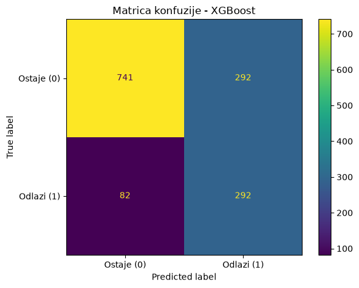

```python
import matplotlib.pyplot as plt
from sklearn.metrics import confusion_matrix, ConfusionMatrixDisplay

cm_xgb = confusion_matrix(y_test, y_pred_xgb)

print("Matrica konfuzije:")
print(cm_xgb)

disp = ConfusionMatrixDisplay(
    confusion_matrix=cm_xgb,
    display_labels=["Ostaje (0)", "Odlazi (1)"]
)

disp.plot()
plt.title("Matrica konfuzije - XGBoost")
plt.tight_layout()

plt.savefig(
    "../images/07_xgb_confusion_matrix.png",
    dpi=100,
    bbox_inches="tight"
)

plt.show()
```

### Tumačenje matrice konfuzije

XGBoost je pravilno prepoznao 292 korisnika koji su zaista otišli (TP), dok mu je 82 takvih korisnika (FN) promaklo. Sa druge strane, 292 korisnika (FP) je označio kao rizične iako su ostali, a 741 korisnika (TN) je tačno prepoznao kao one koji ostaju.

Kod problema churn-a, broj False Negative slučajeva je posebno bitan, jer su to korisnici koji zaista odlaze, a model ih nije prepoznao na vreme. XGBoost ovde ima Recall od 78.07%, što znači da je uhvatio veliki deo korisnika koji su stvarno napustili kompaniju.

Model doduše pravi i određeni broj lažno pozitivnih predikcija, ali to je u poslovnom smislu prihvatljivo, bolje je označiti korisnika kao rizičnog pa da se ispostavi da je ostao, nego propustiti nekoga ko zaista odlazi.

## 5. Poređenje modela

Sad kad smo istrenirali i ocenili sva tri modela, upoređujemo ih jedan naspram drugog po istim metrikama.

Cilj nije da odaberemo model samo po Accuracy-ju, već da uzmemo u obzir sve metrike zajedno. Kod nas je Recall posebno bitan, jer želimo da model prepozna što veći broj korisnika koji stvarno odlaze.

```python
# Kreiramo tabelu sa rezultatima sva tri modela.

rezultati_modela = pd.DataFrame({
    "Model": [
        "Logistička regresija",
        "Random Forest",
        "XGBoost"
    ],
    "Accuracy": [
        accuracy_logreg,
        accuracy_rf,
        accuracy_xgb
    ],
    "Precision": [
        precision_logreg,
        precision_rf,
        precision_xgb
    ],
    "Recall": [
        recall_logreg,
        recall_rf,
        recall_xgb
    ],
    "F1-score": [
        f1_logreg,
        f1_rf,
        f1_xgb
    ],
    "ROC-AUC": [
        roc_auc_logreg,
        roc_auc_rf,
        roc_auc_xgb
    ]
})

# Zaokružujemo rezultate na 4 decimale.
rezultati_modela = rezultati_modela.round(4)

print("POREĐENJE MODELA")
print("=" * 80)

display(rezultati_modela)
```

```
POREĐENJE MODELA
================================================================================
```

|  | Model | Accuracy | Precision | Recall | F1-score | ROC-AUC |
| --- | --- | --- | --- | --- | --- | --- |
| 0 | Logistička regresija | 0.7271 | 0.4916 | 0.7834 | 0.6041 | 0.8328 |
| 1 | Random Forest | 0.7676 | 0.5528 | 0.6578 | 0.6007 | 0.8200 |
| 2 | XGBoost | 0.7342 | 0.5000 | 0.7807 | 0.6096 | 0.8312 |

### 5.2 Grafičko poređenje modela

Pored tabele, iste rezultate prikazujemo i na grafikonu, tako se razlike između modela lakše uočavaju na prvi pogled.

Upoređujemo Accuracy, Precision, Recall, F1-score i ROC-AUC.

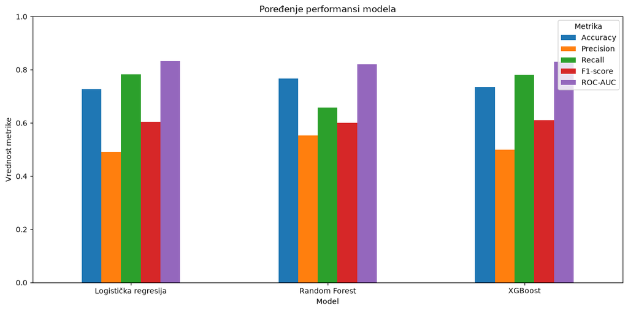

```python
import matplotlib.pyplot as plt

metrike = ["Accuracy", "Precision", "Recall", "F1-score", "ROC-AUC"]

rezultati_modela.set_index("Model")[metrike].plot(
    kind="bar",
    figsize=(12, 6)
)

plt.title("Poređenje performansi modela")
plt.xlabel("Model")
plt.ylabel("Vrednost metrike")
plt.ylim(0, 1)
plt.xticks(rotation=0)
plt.legend(title="Metrika")
plt.tight_layout()

plt.savefig(
    "../images/07_model_comparison.png",
    dpi=100,
    bbox_inches="tight"
)

plt.show()
```

### 5.3 Izbor najboljeg modela

Pri izboru konačnog modela gledamo sve metrike, ali nama su najvažniji Recall i F1-score.

Recall nam pokazuje koliko dobro model prepoznaje korisnike koji zaista odlaze, a F1-score je neka vrsta ravnoteže između Recall-a i Precision-a.

Kad pogledamo rezultate, XGBoost ima najbolji F1-score (0.6096), logistička regresija najbolji Recall (0.7834) i ROC-AUC (0.8328), dok Random Forest ima najbolju Accuracy (0.7676) i Precision (0.5528), ali zato i najniži Recall (0.6578).

Ne postoji, dakle, jedan model koji je bolji od ostalih po svim kriterijumima, izbor zavisi od toga šta nam je u konkretnom slučaju najbitnije.

Kako je nama ovde ključno da uhvatimo što više korisnika koji zaista odlaze, logistička regresija nam deluje kao najbolji izbor, s obzirom na najviši Recall i ROC-AUC. XGBoost joj je ipak ozbiljna konkurencija, zahvaljujući najboljem F1-score-u.

## 6. Analiza važnosti atributa (Feature Importance)

Pored samih metrika, korisno je videti i koji atributi najviše doprinose predikciji. To nam pomaže na dva načina.

Prvo, lakše objašnjavamo poslovnim korisnicima zašto model misli da će neki korisnik otići. Drugo, možemo proveriti da li su nove promenljive koje smo napravili u svesci `05` (`ActiveServices`, `TenureGroup`) zaista korisne modelu, ili su bile suvišne.

Kod Logističke regresije gledamo koeficijente, predznak nam govori u kom pravcu utiču, a veličina koliko jako. Kod Random Forest-a i XGBoost-a koristimo ugrađenu meru `feature_importances_`.

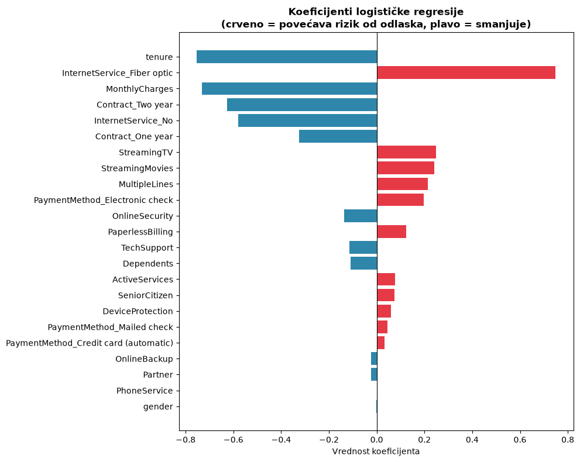

```
Top 5 atributa koji NAJVIŠE POVEĆAVAJU rizik od odlaska:
InternetService_Fiber optic       0.749074
StreamingTV                       0.248231
StreamingMovies                   0.240989
MultipleLines                     0.213523
PaymentMethod_Electronic check    0.197058
dtype: float64

Top 5 atributa koji NAJVIŠE SMANJUJU rizik od odlaska:
tenure               -0.753307
MonthlyCharges       -0.732099
Contract_Two year    -0.627166
InternetService_No   -0.578792
Contract_One year    -0.325476
dtype: float64
```

```python
import numpy as np

koef_logreg = pd.Series(model_logreg.coef_[0], index=X_train_linear.columns)
koef_logreg_sorted = koef_logreg.reindex(koef_logreg.abs().sort_values(ascending=False).index)

plt.figure(figsize=(10, 8))
colors_bar = ["#E63946" if v > 0 else "#2E86AB" for v in koef_logreg_sorted]
plt.barh(koef_logreg_sorted.index[::-1], koef_logreg_sorted.values[::-1], color=colors_bar[::-1])
plt.axvline(0, color="black", linewidth=0.8)
plt.title("Koeficijenti logističke regresije\n(crveno = povećava rizik od odlaska, plavo = smanjuje)", fontweight="bold")
plt.xlabel("Vrednost koeficijenta")
plt.tight_layout()
plt.savefig("../images/07_logreg_coefficients.png", dpi=100, bbox_inches="tight")
plt.show()

print("Top 5 atributa koji NAJVIŠE POVEĆAVAJU rizik od odlaska:")
print(koef_logreg.sort_values(ascending=False).head(5))
print("\nTop 5 atributa koji NAJVIŠE SMANJUJU rizik od odlaska:")
print(koef_logreg.sort_values().head(5))
```

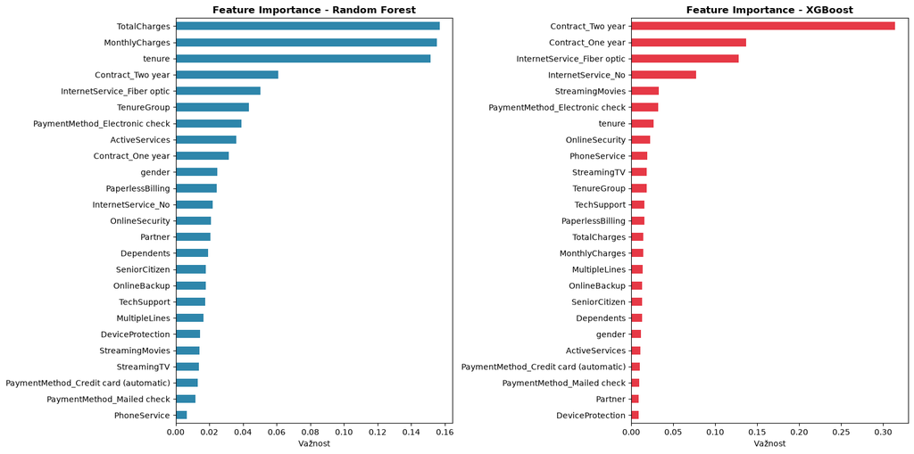

```
Top 5 najvažnijih atributa - Random Forest:
TotalCharges                   0.156775
MonthlyCharges                 0.155241
tenure                         0.151300
Contract_Two year              0.060804
InternetService_Fiber optic    0.050264
dtype: float64

Top 5 najvažnijih atributa - XGBoost:
Contract_Two year              0.314103
Contract_One year              0.137107
InternetService_Fiber optic    0.128058
InternetService_No             0.077220
StreamingMovies                0.032697
dtype: float32
```

```python
importance_rf = pd.Series(model_rf.feature_importances_, index=X_train.columns)
importance_xgb = pd.Series(model_xgb.feature_importances_, index=X_train.columns)

fig, axes = plt.subplots(1, 2, figsize=(16, 8))

importance_rf.sort_values().plot(kind="barh", ax=axes[0], color="#2E86AB")
axes[0].set_title("Feature Importance - Random Forest", fontweight="bold")
axes[0].set_xlabel("Važnost")

importance_xgb.sort_values().plot(kind="barh", ax=axes[1], color="#E63946")
axes[1].set_title("Feature Importance - XGBoost", fontweight="bold")
axes[1].set_xlabel("Važnost")

plt.tight_layout()
plt.savefig("../images/07_feature_importance_rf_xgb.png", dpi=100, bbox_inches="tight")
plt.show()

print("Top 5 najvažnijih atributa - Random Forest:")
print(importance_rf.sort_values(ascending=False).head(5))
print("\nTop 5 najvažnijih atributa - XGBoost:")
print(importance_xgb.sort_values(ascending=False).head(5))
```

### 6.1 Permutaciona važnost atributa

`feature_importances_` kod Random Forest-a i XGBoost-a računa se na drugačiji način kod svakog modela (impurity decrease kod RF, gain kod XGBoost), pa nije striktno uporediva između modela, a kod koreliranih numeričkih kolona (`TotalCharges`, `MonthlyCharges`, `tenure`) impurity importance kod RF-a ume da bude nepouzdana, jer se "zasluga" deli između koreliranih atributa na nasumičan način.

Permutaciona važnost (`sklearn.inspection.permutation_importance`) meri nešto direktnije: za koliko opadne performansa modela na **test skupu** kada se vrednosti jedne kolone nasumično promešaju, čime se ta kolona efektivno "pokvari", a sve ostalo ostaje isto. Pošto se meri u istoj jedinici (pad odabrane metrike) za oba modela, ovo nam daje pravednije poređenje i proveru da li je razilaženje u top 5 atributima između RF-a i XGBoost-a stvarno ili je artefakt načina računanja ugrađene važnosti.

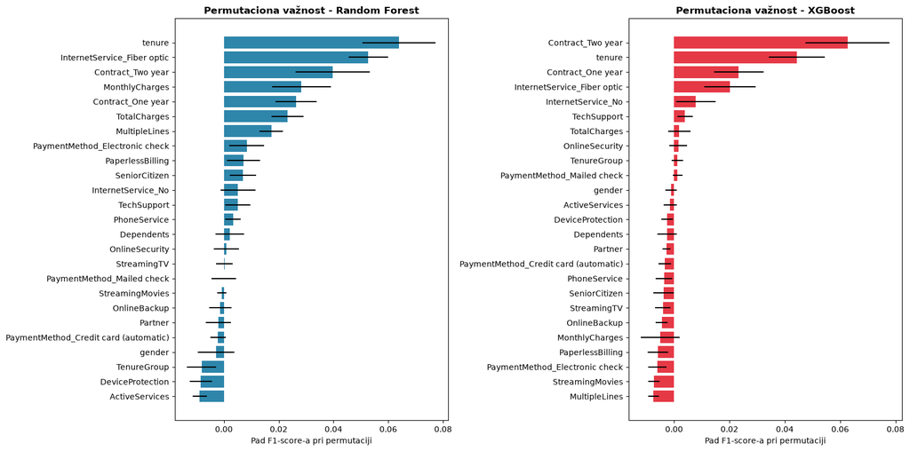

```
Top 5 - permutaciona važnost (Random Forest):
tenure                         0.064004
InternetService_Fiber optic    0.052742
Contract_Two year              0.039771
MonthlyCharges                 0.028317
Contract_One year              0.026327
dtype: float64

Top 5 - permutaciona važnost (XGBoost):
Contract_Two year              0.062695
tenure                         0.044342
Contract_One year              0.023366
InternetService_Fiber optic    0.020170
InternetService_No             0.007857
dtype: float64

Za poređenje, ugrađena (impurity/gain) važnost - top 5:
Random Forest:
TotalCharges                   0.156775
MonthlyCharges                 0.155241
tenure                         0.151300
Contract_Two year              0.060804
InternetService_Fiber optic    0.050264
dtype: float64

XGBoost:
Contract_Two year              0.314103
Contract_One year              0.137107
InternetService_Fiber optic    0.128058
InternetService_No             0.077220
StreamingMovies                0.032697
dtype: float32
```

```python
from sklearn.inspection import permutation_importance

# Permutacionu važnost računamo na TEST skupu, jer nas zanima koliko
# svaki atribut zaista doprinosi generalizaciji modela na nove podatke,
# a ne koliko je "iskorišćen" prilikom građenja stabala na trening skupu.
perm_rf = permutation_importance(
    model_rf, X_test, y_test,
    scoring="f1", n_repeats=10, random_state=42, n_jobs=-1
)
perm_xgb = permutation_importance(
    model_xgb, X_test, y_test,
    scoring="f1", n_repeats=10, random_state=42, n_jobs=-1
)

perm_importance_rf = pd.Series(perm_rf.importances_mean, index=X_test.columns)
perm_importance_xgb = pd.Series(perm_xgb.importances_mean, index=X_test.columns)
perm_std_rf = pd.Series(perm_rf.importances_std, index=X_test.columns)
perm_std_xgb = pd.Series(perm_xgb.importances_std, index=X_test.columns)

fig, axes = plt.subplots(1, 2, figsize=(16, 8))

redosled_rf = perm_importance_rf.sort_values().index
axes[0].barh(redosled_rf, perm_importance_rf[redosled_rf],
             xerr=perm_std_rf[redosled_rf], color="#2E86AB")
axes[0].set_title("Permutaciona važnost - Random Forest", fontweight="bold")
axes[0].set_xlabel("Pad F1-score-a pri permutaciji")

redosled_xgb = perm_importance_xgb.sort_values().index
axes[1].barh(redosled_xgb, perm_importance_xgb[redosled_xgb],
             xerr=perm_std_xgb[redosled_xgb], color="#E63946")
axes[1].set_title("Permutaciona važnost - XGBoost", fontweight="bold")
axes[1].set_xlabel("Pad F1-score-a pri permutaciji")

plt.tight_layout()
plt.savefig("../images/07_permutation_importance_rf_xgb.png", dpi=100, bbox_inches="tight")
plt.show()

print("Top 5 - permutaciona važnost (Random Forest):")
print(perm_importance_rf.sort_values(ascending=False).head(5))
print("\nTop 5 - permutaciona važnost (XGBoost):")
print(perm_importance_xgb.sort_values(ascending=False).head(5))

print("\nZa poređenje, ugrađena (impurity/gain) važnost - top 5:")
print("Random Forest:")
print(importance_rf.sort_values(ascending=False).head(5))
print("\nXGBoost:")
print(importance_xgb.sort_values(ascending=False).head(5))
```

## 7. Cross-validacija

Do sada smo modele evaluirali samo na jednoj podeli trening/test skupa, a rezultati koje smo dobili mogu delom biti stvar slučaja, zavisno od toga koji su korisnici baš završili u test skupu.

Da bismo dobili pouzdaniju procenu, primenjujemo stratifikovanu 5-struku unakrsnu validaciju (Stratified 5-Fold Cross-Validation) na trening skupu. Ideja je da se trening skup podeli na 5 delova, model trenira na 4 dela i testira na petom, i to se ponovi 5 puta tako da svaki deo jednom bude test skup. Konačna ocena je onda prosek svih 5 iteracija.

Bitno je napomenuti da ovo radimo isključivo na trening skupu (`X_train`, `y_train`), test skup i dalje ostaje netaknut i čuva se za finalnu evaluaciju.

```python
from sklearn.model_selection import StratifiedKFold, cross_validate
from sklearn.pipeline import Pipeline

cv = StratifiedKFold(n_splits=5, shuffle=True, random_state=42)
scoring = ["f1", "recall", "roc_auc"]

pipe_logreg = Pipeline([
    ("scaler", StandardScaler()),
    ("model", LogisticRegression(max_iter=1000, class_weight="balanced", random_state=42))
])

cv_results = {}

for naziv, model_cv, X_cv in [
    ("Logistička regresija", pipe_logreg, X_train_linear),
    ("Random Forest", RandomForestClassifier(n_estimators=300, class_weight="balanced", random_state=42, n_jobs=-1), X_train),
    ("XGBoost", XGBClassifier(n_estimators=300, max_depth=4, learning_rate=0.05, subsample=0.8,
                               colsample_bytree=0.8, scale_pos_weight=scale_pos_weight,
                               random_state=42, eval_metric="logloss"), X_train)
]:
    rezultat = cross_validate(model_cv, X_cv, y_train, cv=cv, scoring=scoring, n_jobs=-1)
    cv_results[naziv] = rezultat
    print(f"{naziv}:")
    for metrika in scoring:
        vrednosti = rezultat[f"test_{metrika}"]
        print(f"  {metrika:10s}: {vrednosti.mean():.4f} ± {vrednosti.std():.4f}")
    print()
```

```
Logistička regresija:
  f1        : 0.6307 ± 0.0074
  recall    : 0.7973 ± 0.0149
  roc_auc   : 0.8445 ± 0.0058

Random Forest:
  f1        : 0.6042 ± 0.0181
  recall    : 0.6401 ± 0.0261
  roc_auc   : 0.8318 ± 0.0085

XGBoost:
  f1        : 0.6311 ± 0.0098
  recall    : 0.7672 ± 0.0149
  roc_auc   : 0.8458 ± 0.0043
```

### Tumačenje cross-validacije

Poredeći rezultate cross-validacije sa onim što smo dobili na jednom test skupu (sekcija 5), vidimo da li su performanse stabilne ili je model imao "sreće" sa podelom podataka. Ako je standardna devijacija (± vrednost) kroz 5 foldova mala, znači da model daje slične rezultate bez obzira koji su korisnici u pitanju, a to nam daje više poverenja u dobijene metrike.

S druge strane, da su prosečne vrednosti iz cross-validacije bile znatno drugačije od rezultata na test skupu, to bi bio signal da je test skup možda nereprezentativan i da rezultate treba uzeti sa rezervom.

## 8. Podešavanje hiperparametara

Do sada smo modele puštali sa parametrima koje smo sami odabrali, razumnim ali proizvoljnim. Sad pokušavamo da sistematski nađemo bolju kombinaciju, pomoću pretrage po mreži ili slučajne pretrage, za dva modela koja su se do sada najbolje pokazala: logističku regresiju (najbolji Recall i AUC) i XGBoost (najbolji F1-score).

Pretragu radimo isključivo na trening skupu, uz istu stratifikovanu 5-struku cross-validaciju kao malopre, sa `f1` kao metrikom koju optimizujemo (jer balansira Precision i Recall).

```python
from sklearn.model_selection import GridSearchCV, RandomizedSearchCV
import warnings
warnings.filterwarnings("ignore")  # sklearn ispisuje mnogo deprecation upozorenja za "penalty" parametar

# --- Grid Search za logističku regresiju ---
param_grid_logreg = {
    "model__C": [0.01, 0.1, 1, 10],
    "model__penalty": ["l1", "l2"],
    "model__solver": ["liblinear"]
}

grid_logreg = GridSearchCV(
    pipe_logreg,
    param_grid_logreg,
    cv=cv,
    scoring="f1",
    n_jobs=-1
)
grid_logreg.fit(X_train_linear, y_train)

print("Najbolji parametri (Logistička regresija):", grid_logreg.best_params_)
print(f"Najbolji F1-score (cross-validacija): {grid_logreg.best_score_:.4f}")
```

```
Najbolji parametri (Logistička regresija): {'model__C': 0.1, 'model__penalty': 'l1', 'model__solver': 'liblinear'}
Najbolji F1-score (cross-validacija): 0.6314
```

```python
# --- Randomized Search za XGBoost ---
param_dist_xgb = {
    "n_estimators": [100, 200, 300, 400],
    "max_depth": [3, 4, 5, 6],
    "learning_rate": [0.01, 0.05, 0.1, 0.2],
    "subsample": [0.7, 0.8, 0.9, 1.0],
    "colsample_bytree": [0.7, 0.8, 0.9, 1.0]
}

random_xgb = RandomizedSearchCV(
    XGBClassifier(scale_pos_weight=scale_pos_weight, random_state=42, eval_metric="logloss"),
    param_distributions=param_dist_xgb,
    n_iter=20,
    cv=cv,
    scoring="f1",
    random_state=42,
    n_jobs=-1
)
random_xgb.fit(X_train, y_train)

print("Najbolji parametri (XGBoost):", random_xgb.best_params_)
print(f"Najbolji F1-score (cross-validacija): {random_xgb.best_score_:.4f}")
```

```
Najbolji parametri (XGBoost): {'subsample': 0.7, 'n_estimators': 300, 'max_depth': 4, 'learning_rate': 0.01, 'colsample_bytree': 0.8}
Najbolji F1-score (cross-validacija): 0.6379
```

```python
# --- Evaluacija podešenih modela na test skupu ---
best_logreg = grid_logreg.best_estimator_
best_xgb = random_xgb.best_estimator_

y_pred_logreg_tuned = best_logreg.predict(X_test_linear)
y_prob_logreg_tuned = best_logreg.predict_proba(X_test_linear)[:, 1]

y_pred_xgb_tuned = best_xgb.predict(X_test)
y_prob_xgb_tuned = best_xgb.predict_proba(X_test)[:, 1]

poredjenje_tuning = pd.DataFrame({
    "Model": [
        "Logistička regresija (pre)",
        "Logistička regresija (posle tuning-a)",
        "XGBoost (pre)",
        "XGBoost (posle tuning-a)"
    ],
    "Accuracy": [
        accuracy_score(y_test, y_pred_logreg),
        accuracy_score(y_test, y_pred_logreg_tuned),
        accuracy_score(y_test, y_pred_xgb),
        accuracy_score(y_test, y_pred_xgb_tuned)
    ],
    "Precision": [
        precision_score(y_test, y_pred_logreg),
        precision_score(y_test, y_pred_logreg_tuned),
        precision_score(y_test, y_pred_xgb),
        precision_score(y_test, y_pred_xgb_tuned)
    ],
    "Recall": [
        recall_score(y_test, y_pred_logreg),
        recall_score(y_test, y_pred_logreg_tuned),
        recall_score(y_test, y_pred_xgb),
        recall_score(y_test, y_pred_xgb_tuned)
    ],
    "F1-score": [
        f1_score(y_test, y_pred_logreg),
        f1_score(y_test, y_pred_logreg_tuned),
        f1_score(y_test, y_pred_xgb),
        f1_score(y_test, y_pred_xgb_tuned)
    ],
    "ROC-AUC": [
        roc_auc_score(y_test, y_prob_logreg),
        roc_auc_score(y_test, y_prob_logreg_tuned),
        roc_auc_score(y_test, y_prob_xgb),
        roc_auc_score(y_test, y_prob_xgb_tuned)
    ]
}).round(4)

display(poredjenje_tuning)
```

|  | Model | Accuracy | Precision | Recall | F1-score | ROC-AUC |
| --- | --- | --- | --- | --- | --- | --- |
| 0 | Logistička regresija (pre) | 0.7271 | 0.4916 | 0.7834 | 0.6041 | 0.8328 |
| 1 | Logistička regresija (posle tuning-a) | 0.7271 | 0.4916 | 0.7834 | 0.6041 | 0.8344 |
| 2 | XGBoost (pre) | 0.7342 | 0.5000 | 0.7807 | 0.6096 | 0.8312 |
| 3 | XGBoost (posle tuning-a) | 0.7321 | 0.4975 | 0.8102 | 0.6165 | 0.8412 |

### Tumačenje podešavanja hiperparametara

Ovim poređenjem vidimo da li je sistematska pretraga parametara donela neko poboljšanje u odnosu na vrednosti koje smo ručno odabrali na početku. Čak i kad poboljšanje nije veliko, ovaj korak ima smisla, jer pokazuje da smo do finalnih parametara došli sistematski, a ne proizvoljno, umesto da se oslonimo samo na podrazumevane vrednosti.

Ako se pokaže da podešeni model nije bolji od početnog, ni to nije loš nalaz, znači da je model već blizu svog "plafona" sa ovim skupom atributa, i da bi za dalje poboljšanje trebalo raditi pre svega na novim feature-ima, ne na parametrima.

### Podešavanje praga odlučivanja

Do sada smo klasu dodeljivali po podrazumevanom pravilu: ako je predviđena verovatnoća odlaska ≥ 0,5, korisnik se svrstava u klasu 1. Taj prag nije nikakav prirodni zakon, samo default vrednost, i ne mora biti optimalan za naš problem.

Pošto nam je Recall prioritet (skuplje je propustiti korisnika koji zaista odlazi nego lažno uzbuniti se oko lojalnog), ima smisla proveriti šta se dešava sa Precision, Recall i F1-score kada pomeramo prag naniže ili naviše, umesto da se držimo defaulta bez razmišljanja.

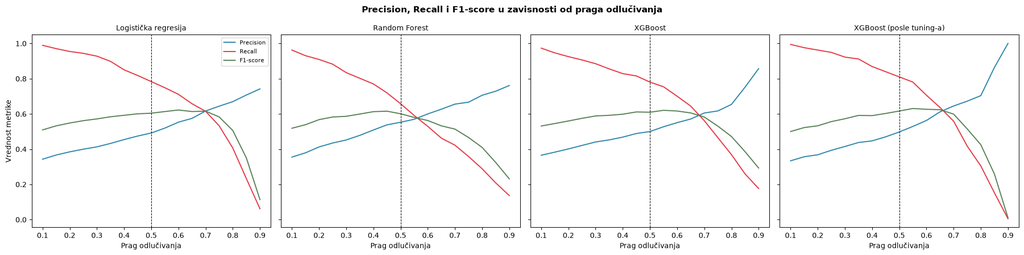

```python
from sklearn.metrics import precision_score, recall_score, f1_score

pragovi = np.arange(0.1, 0.95, 0.05)

verovatnoce_modela = {
    "Logistička regresija": y_prob_logreg,
    "Random Forest": y_prob_rf,
    "XGBoost": y_prob_xgb,
    "XGBoost (posle tuning-a)": y_prob_xgb_tuned,
}

rezultati_pragova = []
for naziv, y_prob in verovatnoce_modela.items():
    for prag in pragovi:
        y_pred_prag = (y_prob >= prag).astype(int)
        rezultati_pragova.append({
            "Model": naziv,
            "Prag": round(prag, 2),
            "Precision": precision_score(y_test, y_pred_prag, zero_division=0),
            "Recall": recall_score(y_test, y_pred_prag),
            "F1-score": f1_score(y_test, y_pred_prag)
        })

df_pragovi = pd.DataFrame(rezultati_pragova)

fig, axes = plt.subplots(1, len(verovatnoce_modela), figsize=(20, 5), sharey=True)
for ax, naziv in zip(axes, verovatnoce_modela.keys()):
    podskup = df_pragovi[df_pragovi["Model"] == naziv]
    ax.plot(podskup["Prag"], podskup["Precision"], label="Precision", color="#2E86AB")
    ax.plot(podskup["Prag"], podskup["Recall"], label="Recall", color="#E63946")
    ax.plot(podskup["Prag"], podskup["F1-score"], label="F1-score", color="#588157")
    ax.axvline(0.5, color="black", linestyle="--", linewidth=0.8)
    ax.set_title(naziv, fontsize=10)
    ax.set_xlabel("Prag odlučivanja")

axes[0].set_ylabel("Vrednost metrike")
axes[0].legend(fontsize=8)
plt.suptitle("Precision, Recall i F1-score u zavisnosti od praga odlučivanja", fontweight="bold")
plt.tight_layout()
plt.savefig("../images/07_pragovi_odlucivanja.png", dpi=100, bbox_inches="tight")
plt.show()
```

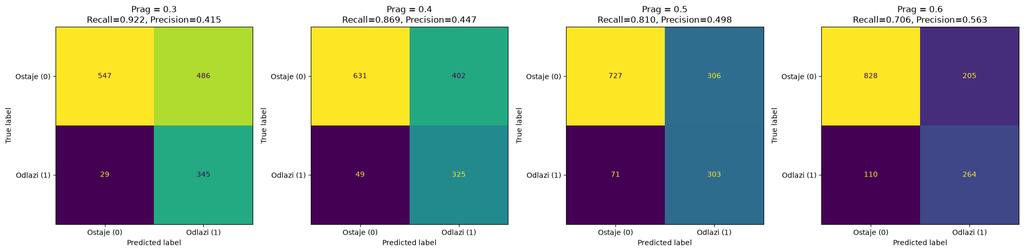

```python
izabrani_pragovi = [0.3, 0.4, 0.5, 0.6]

fig, axes = plt.subplots(1, len(izabrani_pragovi), figsize=(20, 5))
for ax, prag in zip(axes, izabrani_pragovi):
    y_pred_prag = (y_prob_xgb_tuned >= prag).astype(int)
    cm_prag = confusion_matrix(y_test, y_pred_prag)
    disp = ConfusionMatrixDisplay(confusion_matrix=cm_prag, display_labels=["Ostaje (0)", "Odlazi (1)"])
    disp.plot(ax=ax, colorbar=False)
    ax.set_title(
        f"Prag = {prag}\n"
        f"Recall={recall_score(y_test, y_pred_prag):.3f}, "
        f"Precision={precision_score(y_test, y_pred_prag, zero_division=0):.3f}"
    )

plt.tight_layout()
plt.savefig("../images/07_matrice_po_pragovima.png", dpi=100, bbox_inches="tight")
plt.show()
```

Kao što se vidi na grafiku, spuštanje praga ispod 0,5 dosledno povećava Recall, ali po cenu Precision-a i F1-score-a. Za XGBoost (posle tuning-a): na pragu 0,3 Recall raste na 92,25% (sa 81,02% na pragu 0,5), ali Precision pada na 41,52% (sa 49,75%), a F1-score opada sa 0,6165 na 0,5726. Na pragu 0,4 je odnos blaži (Recall 86,90%, Precision 44,70%, F1 0,5904), ali i dalje niži F1 nego na 0,5. F1-score je zapravo maksimalan negde oko praga 0,55, a ne na 0,3-0,4.

Ipak, pošto nam je kod churn problema Recall poslovni prioritet, a ne F1-score sam po sebi, spuštanje praga na 0,3 ili 0,4 i dalje može biti opravdano: broj propuštenih stvarnih odlazaka (FN) pada sa 71 (na pragu 0,5) na svega 29 (na pragu 0,3), po cenu znatno više lažnih alarma (FP raste sa 306 na 486). Prag iznad 0,5 ide u suprotnom smeru (viši Precision, niži Recall) i nije u skladu sa našim prioritetom.

## 9. ROC krive: grafičko poređenje modela

ROC (Receiver Operating Characteristic) kriva pokazuje odnos između True Positive Rate-a (Recall) i False Positive Rate-a, za sve moguće pragove odlučivanja modela. Što je kriva bliža gornjem levom uglu, to model bolje razdvaja dve klase. AUC, površina ispod krive, sve to svodi na jedan broj, što je bliže 1, model je bolji.

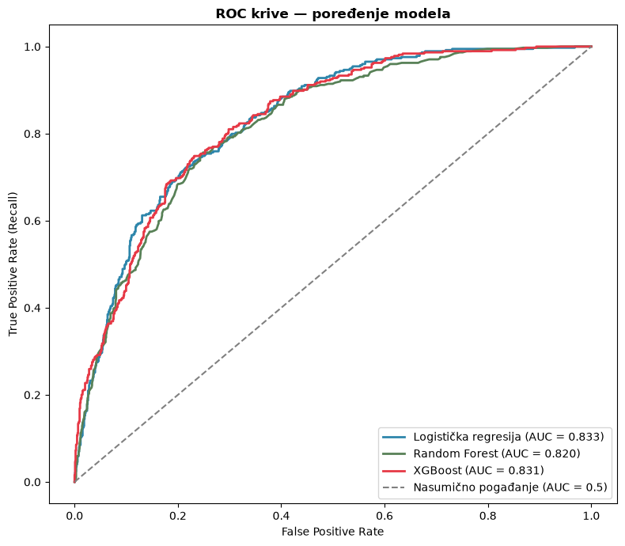

```python
from sklearn.metrics import roc_curve

plt.figure(figsize=(8, 7))

for naziv, y_prob, boja in [
    ("Logistička regresija", y_prob_logreg, "#2E86AB"),
    ("Random Forest", y_prob_rf, "#588157"),
    ("XGBoost", y_prob_xgb, "#E63946"),
]:
    fpr, tpr, _ = roc_curve(y_test, y_prob)
    auc_val = roc_auc_score(y_test, y_prob)
    plt.plot(fpr, tpr, label=f"{naziv} (AUC = {auc_val:.3f})", color=boja, linewidth=2)

plt.plot([0, 1], [0, 1], linestyle="--", color="gray", label="Nasumično pogađanje (AUC = 0.5)")
plt.xlabel("False Positive Rate")
plt.ylabel("True Positive Rate (Recall)")
plt.title("ROC krive — poređenje modela", fontweight="bold")
plt.legend(loc="lower right")
plt.tight_layout()
plt.savefig("../images/07_roc_curves.png", dpi=100, bbox_inches="tight")
plt.show()
```

## 10. Zaključak

U ovoj svesci smo izgradili i ocenili tri modela za predviđanje odlaska korisnika: logističku regresiju, Random Forest i XGBoost.

Sva tri smo trenirali na trening skupu i proverili na nezavisnom test skupu, kroz Accuracy, Precision, Recall, F1-score i ROC-AUC.

Kad pogledamo rezultate, Random Forest ima najveću Accuracy, logistička regresija najveći Recall i ROC-AUC, a XGBoost najbolji F1-score.

Pošto nam je kod churn-a najbitnije da na vreme prepoznamo korisnike koji odlaze, Recall je za nas ključna metrika, i po tom kriterijumu logistička regresija se izdvaja kao najpogodniji izbor, dok je XGBoost i dalje ozbiljna alternativa zahvaljujući najboljem F1-score-u.

Ovi modeli su dobra osnova za dalju optimizaciju i eventualno finije podešavanje parametara.

# 08 - Objedinjeni zaključak projekta

Ova sveska je završna sinteza celog projekta *Telco Customer Churn*. Prethodne sveske (`00`-`07`) su svaka pokrivale po jedan korak analize sa svojim, lokalnim zaključkom, a ovde sve te nalaze povezujemo u jedinstvenu celinu: šta smo saznali o korisnicima koji napuštaju kompaniju, koji je model najbolji izbor i zašto, i šta bi kompanija konkretno trebalo da uradi na osnovu svega ovoga.

## 1. Tok projekta: pregled

| Sveska | Sadržaj |
| --- | --- |
| `00` | Definisanje problema, konteksta i cilja (binarna klasifikacija) |
| `01` | Inicijalni pregled: dimenzije, tipovi, skrivene nedostajuće vrednosti u `TotalCharges` |
| `02` | Provera sistematskih/logičkih grešaka između povezanih kolona |
| `03` | Stratifikovana podela na trening (80%) i test (20%) skup |
| `04` | Detekcija statističkih anomalija (IQR), skup je statistički čist |
| `05` | Feature engineering (`ActiveServices`, `TenureGroup`) i enkodiranje |
| `06` | Iterativna EDA, statistička potvrda ključnih prediktora |
| `07` | Modelovanje, cross-validacija, tuning hiperparametara, ROC krive |
| `08` | *(ova sveska)*, sinteza i poslovne preporuke |

Kroz ceo proces smo se držali istog principa: sve odluke o čišćenju, transformaciji i feature engineering-u donosimo isključivo na trening skupu, dok test skup ostaje netaknut sve do finalne evaluacije. Tako smo izbegli *data leakage*.

## 2. Ključni nalazi o korisnicima koji napuštaju kompaniju

Iz statističke analize (sveska `06`) i analize važnosti atributa (sveska `07`) izdvaja se nekoliko obrazaca, svi statistički potvrđeni (p < 0.05) i prisutni kod sva tri modela.

Dužina pretplate (`tenure`) je takođe usko povezana sa odlaskom. Korisnici koji odlaze imaju u proseku mnogo kraći staž, što ima smisla, rizik je najveći u prvim mesecima, pre nego što se korisnik "navikne" na uslugu.

Tip internet usluge igra veću ulogu nego što bismo očekivali. Korisnici sa `Fiber optic` internetom imaju, paradoksalno, viši churn (oko 42%) od korisnika sa `DSL` (oko 19%). Mogući razlog je viša cena ili razlike u kvalitetu usluge i konkurenciji na tom delu tržišta, ovo je nešto što bi kompanija trebalo dodatno da istraži.

Način plaćanja takođe govori nešto o angažovanosti korisnika. Korisnici koji plaćaju preko `Electronic check`-a, najmanje automatizovanog načina plaćanja, napuštaju znatno češće (oko 45%) od onih sa automatskim plaćanjem (oko 15-19%).

Treba napomenuti da su ovo sve korelacije potvrđene testovima i modelima, ne dokazana uzročno-posledična veza. Ne znamo, na primer, da li duži ugovor zaista uzrokuje lojalnost, ili jednostavno lojalniji korisnici biraju duže ugovore. Da bismo to zaista utvrdili, trebalo bi sprovesti kontrolisan eksperiment, na primer A/B test ponude dužih ugovora.

```python
import pandas as pd

# Rezime finalnih rezultata sva tri modela (pre podešavanja hiperparametara).
# Vrednosti preuzete iz finalnog izvršavanja sveske 07, nakon usklađivanja
# X_train/X_train_linear kroz cross-validaciju i Grid/Randomized Search.
rezime_finalni = pd.DataFrame({
    "Model": ["Logistička regresija", "Random Forest", "XGBoost"],
    "Accuracy": [0.7271, 0.7676, 0.7342],
    "Precision": [0.4916, 0.5528, 0.5000],
    "Recall": [0.7834, 0.6578, 0.7807],
    "F1-score": [0.6041, 0.6007, 0.6096],
    "ROC-AUC": [0.8328, 0.8200, 0.8312]
})
print("Rezultati na test skupu (originalni modeli):")
display(rezime_finalni)

rezime_tuning = pd.DataFrame({
    "Model": ["Logistička regresija (posle tuning-a)", "XGBoost (posle tuning-a)"],
    "Accuracy": [0.7271, 0.7321],
    "Precision": [0.4916, 0.4975],
    "Recall": [0.7834, 0.8102],
    "F1-score": [0.6041, 0.6165],
    "ROC-AUC": [0.8344, 0.8412]
})
print("\nRezultati posle podešavanja hiperparametara:")
display(rezime_tuning)
```

```
Rezultati na test skupu (originalni modeli):
```

|  | Model | Accuracy | Precision | Recall | F1-score | ROC-AUC |
| --- | --- | --- | --- | --- | --- | --- |
| 0 | Logistička regresija | 0.7271 | 0.4916 | 0.7834 | 0.6041 | 0.8328 |
| 1 | Random Forest | 0.7676 | 0.5528 | 0.6578 | 0.6007 | 0.8200 |
| 2 | XGBoost | 0.7342 | 0.5000 | 0.7807 | 0.6096 | 0.8312 |

```
Rezultati posle podešavanja hiperparametara:
```

|  | Model | Accuracy | Precision | Recall | F1-score | ROC-AUC |
| --- | --- | --- | --- | --- | --- | --- |
| 0 | Logistička regresija (posle tuning-a) | 0.7271 | 0.4916 | 0.7834 | 0.6041 | 0.8344 |
| 1 | XGBoost (posle tuning-a) | 0.7321 | 0.4975 | 0.8102 | 0.6165 | 0.8412 |

## 3. Koji model preporučujemo: finalna odluka

Nijedan model nije bolji od ostalih po svim metrikama, pa izbor zavisi od toga šta nam je poslovno prioritet.

Random Forest ima najveću Accuracy (76,8%) i Precision (55,3%), ali i najniži Recall (65,8%) od sva tri modela — propušta oko trećine korisnika koji zaista odlaze. Cross-validacija iz sveske `07` potvrđuje da je ovo stabilan rezultat: prosečan CV recall je oko 64,0%, blizu vrednosti dobijene na test skupu.

Logistička regresija ima najviši Recall (78,3%) i ROC-AUC (83,3%), i uz to je najjednostavnija i najlakša za tumačenje, koeficijenti se direktno čitaju.

XGBoost je najbolje balansiran (najviši F1-score), a posle podešavanja hiperparametara dostiže i najviši ROC-AUC (84,1%), uz Recall od 81,0%, što je ukupno najbolji rezultat od svih koje smo testirali.

Kako je kod predviđanja churn-a mnogo skuplje propustiti korisnika koji odlazi (False Negative) nego pogrešno uzbuniti se oko lojalnog korisnika (False Positive), Recall nam je ovde prioritet. Zbog toga preporučujemo XGBoost sa podešenim hiperparametrima kao finalni model, ima najbolju kombinaciju Recall-a (81,0%) i ROC-AUC-a (84,1%) od svih varijanti koje smo probali. Logistička regresija ostaje dobra alternativa tamo gde je bitnija interpretabilnost, na primer kad treba objasniti odluku korisničkoj podršci ili regulatoru.

## 5. Ograničenja rada i predlozi za dalje unapređenje

Vredi iskreno reći i gde ovaj rad ima granice, to je i samo po sebi deo dobre analitičke prakse.

Performanse su solidne, ali ne izuzetne. F1-score od oko 0,61 nije loš rezultat za skup ove veličine i ovakve nebalansiranosti, ali svakako ima prostora za bolje. Kao sledeći korak, moglo bi se probati SMOTE za sintetičko balansiranje klasa umesto samo `class_weight`, ili šira pretraga hiperparametara, na primer veći `n_iter` kod RandomizedSearchCV-a.

Takođe, kao što smo već pomenuli u sekciji 2, ono što smo pronašli su korelacije, a ne dokazana uzročnost. Za poslovne odluke većeg obima bilo bi pametno te nalaze dodatno proveriti kroz kontrolisan eksperiment.

Na kraju, ovaj rad se zaustavlja na evaluaciji na statičnom test skupu i ne prati kako bi se model ponašao u produkciji. Za realnu primenu bi trebalo periodično ponovo trenirati model i pratiti da li mu performanse padaju tokom vremena, kako se ponašanje korisnika menja.

## 6. Poslovne preporuke

Na osnovu svega što smo pronašli, evo konkretnih preporuka za telekomunikacionu kompaniju.

Prvo, vredi prioritetno targetirati korisnike sa Month-to-month ugovorom, to je najveći pojedinačni faktor rizika, i ponuda popusta za prelazak na godišnji ili dvogodišnji ugovor bi mogla značajno da smanji odliv.

Drugo, posebnu pažnju treba posvetiti prvih 6-12 meseci pretplate, jer je to period kad je rizik od odlaska najveći, pa bi tu imalo smisla uvesti proaktivnu podršku ili uvodne popuste.

Treće, korisnike bi trebalo podsticati da koriste dodatne usluge poput `TechSupport` i `OnlineSecurity`, jer su ti korisnici lojalniji, verovatno zato što bi prelaskom kod drugog provajdera izgubili više funkcionalnosti.

Četvrto, vredelo bi dodatno istražiti zašto je churn kod korisnika sa Fiber optic internetom toliki, nije jasno da li je razlog cena, kvalitet usluge ili konkurencija, i pre donošenja konkretnih mera trebalo bi to dodatno analizirati.

Peto, korisnike bi trebalo podsticati da pređu na automatsko plaćanje, s obzirom na to da korisnici koji plaćaju preko `Electronic check`-a odlaze znatno češće, pa bi olakšavanje prelaska na plaćanje karticom ili preko banke moglo pomoći.

## 7. Zaključna reč

Kroz ovaj projekat smo prošli ceo tok analize podataka, od sirovog CSV fajla, preko čišćenja i statistički potvrđene eksplorativne analize, feature engineering-a, pa sve do tri istrenirana i validirana modela sa sistematski podešenim hiperparametrima. Rezultati pokazuju da je churn kod ovog skupa podataka predvidiv u razumnoj meri (ROC-AUC oko 0,84), a faktori rizika koje smo identifikovali imaju smisla i sa poslovne, ne samo statističke strane.

Kod, dataset i sve sveske dostupni su u GitHub repozitorijumu tima.